# Predict Bike Sharing Demand with AutoGluon Template

## Project: Predict Bike Sharing Demand with AutoGluon

This notebook is a template with each step that you need to complete for the project.

Please fill in your code where there are explicit `?` markers in the notebook. You are welcome to add more cells and code as you see fit.

Once you have completed all the code implementations, please export your notebook as a HTML file so the reviews can view your code. Make sure you have all outputs correctly outputted.

`File-> Export Notebook As... -> Export Notebook as HTML`

There is a writeup to complete as well after all code implememtation is done. Please answer all questions and attach the necessary tables and charts. You can complete the writeup in either markdown or PDF.

Completing the code template and writeup template will cover all of the rubric points for this project.

The rubric contains "Stand Out Suggestions" for enhancing the project beyond the minimum requirements. The stand out suggestions are optional. If you decide to pursue the "stand out suggestions", you can include the code in this notebook and also discuss the results in the writeup file.

## Step 1: Create an account with Kaggle

### Create Kaggle Account and download API key

Below is example of steps to get the API username and key. Each student will have their own username and key.

1. Open account settings.

2. Scroll down to API and click Create New API Token.

3. Open up `kaggle.json` and use the username and key.


## Step 2: Download the Kaggle dataset using the kaggle python library

### Open up Sagemaker Studio and use starter template

1. Notebook should be using a `ml.t3.medium` instance (2 vCPU + 4 GiB)
2. Notebook should be using kernal: `Python 3 (MXNet 1.8 Python 3.7 CPU Optimized)`

I am changing and running this notebook in kaggle itself as a kaggle notebook as I was facing issues regarding version dependencies. So the some parts of the code is changes accordingly especially to load the dataset.

### Install packages

```python
!pip install -U pip
!pip install -U setuptools wheel
!pip install -U "mxnet<2.0.0" bokeh==2.0.1
!pip install autogluon --no-cache-dir
# Without --no-cache-dir, smaller aws instances may have trouble installing
```

```python
!pip install scikit-learn==1.1.3
```

[output not shown]

### Setup Kaggle API Key

```python
#I have commented this code cell because I am directly attaching the input through kaggle itself.
# create the .kaggle directory and an empty kaggle.json file
# !mkdir -p /root/.kaggle
# !touch /root/.kaggle/kaggle.json
# !chmod 600 /root/.kaggle/kaggle.json
```

### Download and explore dataset

### Go to the bike sharing demand competition and agree to the terms

```python
# # Download the dataset, it will be in a .zip file so you'll need to unzip it as well.
# !kaggle competitions download -c bike-sharing-demand
# # If you already downloaded it you can use the -o command to overwrite the file
# !unzip -o bike-sharing-demand.zip
```

```python
import pandas as pd
from autogluon.tabular import TabularPredictor
```

```python
# Create the train dataset in pandas by reading the csv
# Set the parsing of the datetime column so you can use some of the `dt` features in pandas later
train = pd.read_csv("/kaggle/input/bike-sharing-demand/train.csv",parse_dates=["datetime"])
train.head()
```

|  | datetime | season | holiday | workingday | weather | temp | atemp | humidity | windspeed | casual | registered | count |
| --- | --- | --- | --- | --- | --- | --- | --- | --- | --- | --- | --- | --- |
| 0 | 2011-01-01 00:00:00 | 1 | 0 | 0 | 1 | 9.84 | 14.395 | 81 | 0.0 | 3 | 13 | 16 |
| 1 | 2011-01-01 01:00:00 | 1 | 0 | 0 | 1 | 9.02 | 13.635 | 80 | 0.0 | 8 | 32 | 40 |
| 2 | 2011-01-01 02:00:00 | 1 | 0 | 0 | 1 | 9.02 | 13.635 | 80 | 0.0 | 5 | 27 | 32 |
| 3 | 2011-01-01 03:00:00 | 1 | 0 | 0 | 1 | 9.84 | 14.395 | 75 | 0.0 | 3 | 10 | 13 |
| 4 | 2011-01-01 04:00:00 | 1 | 0 | 0 | 1 | 9.84 | 14.395 | 75 | 0.0 | 0 | 1 | 1 |

```python
print(train.dtypes)
```

```
datetime      datetime64[ns]
season                 int64
holiday                int64
workingday             int64
weather                int64
temp                 float64
atemp                float64
humidity               int64
windspeed            float64
casual                 int64
registered             int64
count                  int64
dtype: object
```

```python
# Simple output of the train dataset to view some of the min/max/varition of the dataset features.
train.describe()
```

|  | datetime | season | holiday | workingday | weather | temp | atemp | humidity | windspeed | casual | registered | count |
| --- | --- | --- | --- | --- | --- | --- | --- | --- | --- | --- | --- | --- |
| count | 10886 | 10886.000000 | 10886.000000 | 10886.000000 | 10886.000000 | 10886.00000 | 10886.000000 | 10886.000000 | 10886.000000 | 10886.000000 | 10886.000000 | 10886.000000 |
| mean | 2011-12-27 05:56:22.399411968 | 2.506614 | 0.028569 | 0.680875 | 1.418427 | 20.23086 | 23.655084 | 61.886460 | 12.799395 | 36.021955 | 155.552177 | 191.574132 |
| min | 2011-01-01 00:00:00 | 1.000000 | 0.000000 | 0.000000 | 1.000000 | 0.82000 | 0.760000 | 0.000000 | 0.000000 | 0.000000 | 0.000000 | 1.000000 |
| 25% | 2011-07-02 07:15:00 | 2.000000 | 0.000000 | 0.000000 | 1.000000 | 13.94000 | 16.665000 | 47.000000 | 7.001500 | 4.000000 | 36.000000 | 42.000000 |
| 50% | 2012-01-01 20:30:00 | 3.000000 | 0.000000 | 1.000000 | 1.000000 | 20.50000 | 24.240000 | 62.000000 | 12.998000 | 17.000000 | 118.000000 | 145.000000 |
| 75% | 2012-07-01 12:45:00 | 4.000000 | 0.000000 | 1.000000 | 2.000000 | 26.24000 | 31.060000 | 77.000000 | 16.997900 | 49.000000 | 222.000000 | 284.000000 |
| max | 2012-12-19 23:00:00 | 4.000000 | 1.000000 | 1.000000 | 4.000000 | 41.00000 | 45.455000 | 100.000000 | 56.996900 | 367.000000 | 886.000000 | 977.000000 |
| std | NaN | 1.116174 | 0.166599 | 0.466159 | 0.633839 | 7.79159 | 8.474601 | 19.245033 | 8.164537 | 49.960477 | 151.039033 | 181.144454 |

```python
train.isnull().sum()
```

```
datetime      0
season        0
holiday       0
workingday    0
weather       0
temp          0
atemp         0
humidity      0
windspeed     0
casual        0
registered    0
count         0
dtype: int64
```

```python
# Create the test pandas dataframe in pandas by reading the csv, remember to parse the datetime!
test = pd.read_csv("/kaggle/input/bike-sharing-demand/test.csv",parse_dates=['datetime'])
test.head()
```

|  | datetime | season | holiday | workingday | weather | temp | atemp | humidity | windspeed |
| --- | --- | --- | --- | --- | --- | --- | --- | --- | --- |
| 0 | 2011-01-20 00:00:00 | 1 | 0 | 1 | 1 | 10.66 | 11.365 | 56 | 26.0027 |
| 1 | 2011-01-20 01:00:00 | 1 | 0 | 1 | 1 | 10.66 | 13.635 | 56 | 0.0000 |
| 2 | 2011-01-20 02:00:00 | 1 | 0 | 1 | 1 | 10.66 | 13.635 | 56 | 0.0000 |
| 3 | 2011-01-20 03:00:00 | 1 | 0 | 1 | 1 | 10.66 | 12.880 | 56 | 11.0014 |
| 4 | 2011-01-20 04:00:00 | 1 | 0 | 1 | 1 | 10.66 | 12.880 | 56 | 11.0014 |

```python
# Shape of train and test datasets
print("Train Dataset Shape : ", train.shape)
print("Test Dataset Shape  : ", test.shape)
```

```
Train Dataset Shape :  (10886, 12)
Test Dataset Shape  :  (6493, 9)
```

```python
# Same thing as train and test dataset
submission = pd.read_csv("/kaggle/input/bike-sharing-demand/sampleSubmission.csv",parse_dates=['datetime'])
submission.head()
```

|  | datetime | count |
| --- | --- | --- |
| 0 | 2011-01-20 00:00:00 | 0 |
| 1 | 2011-01-20 01:00:00 | 0 |
| 2 | 2011-01-20 02:00:00 | 0 |
| 3 | 2011-01-20 03:00:00 | 0 |
| 4 | 2011-01-20 04:00:00 | 0 |

```python
# Checking all the features and target variable in the dataset
print("Columns in Train Dataset:\n", train.columns)
print("\nColumns in Test Dataset:\n", test.columns)
```

```
Columns in Train Dataset:
 Index(['datetime', 'season', 'holiday', 'workingday', 'weather', 'temp',
       'atemp', 'humidity', 'windspeed', 'casual', 'registered', 'count'],
      dtype='object')

Columns in Test Dataset:
 Index(['datetime', 'season', 'holiday', 'workingday', 'weather', 'temp',
       'atemp', 'humidity', 'windspeed'],
      dtype='object')
```

## Step 3: Train a model using AutoGluon’s Tabular Prediction

Requirements:

- We are prediting `count`, so it is the label we are setting.
- Ignore `casual` and `registered` columns as they are also not present in the test dataset.
- Use the `root_mean_squared_error` as the metric to use for evaluation.
- Set a time limit of 10 minutes (600 seconds).
- Use the preset `best_quality` to focus on creating the best model.

```python
label = 'count'
ignored_columns = ["casual","registered"]
eval_metric = "root_mean_squared_error"
train_data = train
time_limit = 600
presets = "best_quality"
```

```python
#Because I am running this on kaggle, avoiding XGBoost as the versions arenot compatible
predictor = TabularPredictor(label=label, problem_type= 'regression', eval_metric=eval_metric, learner_kwargs={'ignored_columns': ignored_columns}).fit(
                                                                           train_data = train_data,excluded_model_types=["XGBoost"],time_limit=time_limit,presets=presets)
```

[output not shown]

[output cut: 33 more lines]

```
(_dystack pid=18391) 	'KNN': [{'weights': 'uniform', 'ag_args': {'name_suffix': 'Unif'}}, {'weights': 'distance', 'ag_args': {'name_suffix': 'Dist'}}],
(_dystack pid=18391) }
(_dystack pid=18391) AutoGluon will fit 2 stack levels (L1 to L2) ...
(_dystack pid=18391) Excluded models: [] (Specified by `excluded_model_types`)
(_dystack pid=18391) Fitting 108 L1 models, fit_strategy="sequential" ...
(_dystack pid=18391) Fitting model: KNeighborsUnif_BAG_L1 ... Training model for up to 96.97s of the 145.48s of remaining time.
(_dystack pid=18391) 	-107.3366	 = Validation score   (-root_mean_squared_error)
(_dystack pid=18391) 	0.16s	 = Training   runtime
(_dystack pid=18391) 	0.04s	 = Validation runtime
(_dystack pid=18391) Fitting model: KNeighborsDist_BAG_L1 ... Training model for up to 94.70s of the 143.21s of remaining time.
(_dystack pid=18391) 	-89.8997	 = Validation score   (-root_mean_squared_error)
(_dystack pid=18391) 	0.01s	 = Training   runtime
(_dystack pid=18391) 	0.04s	 = Validation runtime
(_dystack pid=18391) Fitting model: LightGBMXT_BAG_L1 ... Training model for up to 94.64s of the 143.15s of remaining time.
(_dystack pid=18391) 	Fitting 8 child models (S1F1 - S1F8) | Fitting with ParallelLocalFoldFittingStrategy (4 workers, per: cpus=1, gpus=0, memory=0.04%)
```

```
(_ray_fit pid=18605) [1000]	valid_set's rmse: 130.657
(_ray_fit pid=18738) [1000]	valid_set's rmse: 128.154 [repeated 6x across cluster] (Ray deduplicates logs by default. Set RAY_DEDUP_LOGS=0 to disable log deduplication, or see https://docs.ray.io/en/master/ray-observability/user-guides/configure-logging.html#log-deduplication for more options.)
(_ray_fit pid=18738) [4000]	valid_set's rmse: 125.904 [repeated 7x across cluster]
(_ray_fit pid=18775) [5000]	valid_set's rmse: 132.706 [repeated 9x across cluster]
(_ray_fit pid=18738) [9000]	valid_set's rmse: 125.618 [repeated 11x across cluster]
```

```
(_dystack pid=18391) 	-131.9758	 = Validation score   (-root_mean_squared_error)
(_dystack pid=18391) 	34.08s	 = Training   runtime
(_dystack pid=18391) 	6.51s	 = Validation runtime
(_dystack pid=18391) Fitting model: LightGBM_BAG_L1 ... Training model for up to 54.89s of the 103.40s of remaining time.
(_dystack pid=18391) 	Fitting 8 child models (S1F1 - S1F8) | Fitting with ParallelLocalFoldFittingStrategy (4 workers, per: cpus=1, gpus=0, memory=0.04%)
```

```
(_ray_fit pid=18885) [1000]	valid_set's rmse: 135.098 [repeated 4x across cluster]
(_ray_fit pid=19016) [1000]	valid_set's rmse: 124.896 [repeated 3x across cluster]
```

```
(_dystack pid=18391) 	-131.8496	 = Validation score   (-root_mean_squared_error)
(_dystack pid=18391) 	16.44s	 = Training   runtime
(_dystack pid=18391) 	1.26s	 = Validation runtime
(_dystack pid=18391) Fitting model: RandomForestMSE_BAG_L1 ... Training model for up to 34.74s of the 83.25s of remaining time.
(_dystack pid=18391) 	-119.5485	 = Validation score   (-root_mean_squared_error)
(_dystack pid=18391) 	5.33s	 = Training   runtime
(_dystack pid=18391) 	0.55s	 = Validation runtime
(_dystack pid=18391) Fitting model: CatBoost_BAG_L1 ... Training model for up to 28.46s of the 76.98s of remaining time.
(_dystack pid=18391) 	Fitting 8 child models (S1F1 - S1F8) | Fitting with ParallelLocalFoldFittingStrategy (4 workers, per: cpus=1, gpus=0, memory=1.34%)
(_ray_fit pid=19165) 	Ran out of time, early stopping on iteration 2006.
(_ray_fit pid=19316) 	Ran out of time, early stopping on iteration 1869. [repeated 2x across cluster]
(_dystack pid=18391) 	-132.3146	 = Validation score   (-root_mean_squared_error)
(_dystack pid=18391) 	26.48s	 = Training   runtime
(_dystack pid=18391) 	0.07s	 = Validation runtime
(_dystack pid=18391) Fitting model: WeightedEnsemble_L2 ... Training model for up to 145.49s of the 47.06s of remaining time.
(_dystack pid=18391) 	Ensemble Weights: {'KNeighborsDist_BAG_L1': 1.0}
(_dystack pid=18391) 	-89.8997	 = Validation score   (-root_mean_squared_error)
(_dystack pid=18391) 	0.02s	 = Training   runtime
(_dystack pid=18391) 	0.0s	 = Validation runtime
(_dystack pid=18391) Excluded models: [] (Specified by `excluded_model_types`)
(_dystack pid=18391) Fitting 106 L2 models, fit_strategy="sequential" ...
(_dystack pid=18391) Fitting model: LightGBMXT_BAG_L2 ... Training model for up to 47.04s of the 47.02s of remaining time.
(_dystack pid=18391) 	Fitting 8 child models (S1F1 - S1F8) | Fitting with ParallelLocalFoldFittingStrategy (4 workers, per: cpus=1, gpus=0, memory=0.05%)
```

```
(_ray_fit pid=19507) [1000]	valid_set's rmse: 70.526 [repeated 4x across cluster]
(_ray_fit pid=19645) [1000]	valid_set's rmse: 76.694 [repeated 4x across cluster]
```

```
(_dystack pid=18391) 	-73.5734	 = Validation score   (-root_mean_squared_error)
(_dystack pid=18391) 	19.68s	 = Training   runtime
(_dystack pid=18391) 	1.64s	 = Validation runtime
(_dystack pid=18391) Fitting model: LightGBM_BAG_L2 ... Training model for up to 23.12s of the 23.09s of remaining time.
(_dystack pid=18391) 	Fitting 8 child models (S1F1 - S1F8) | Fitting with ParallelLocalFoldFittingStrategy (4 workers, per: cpus=1, gpus=0, memory=0.05%)
(_ray_fit pid=19394) 	Ran out of time, early stopping on iteration 2316. [repeated 3x across cluster]
(_dystack pid=18391) 	-68.0349	 = Validation score   (-root_mean_squared_error)
(_dystack pid=18391) 	14.26s	 = Training   runtime
(_dystack pid=18391) 	0.19s	 = Validation runtime
(_dystack pid=18391) Fitting model: RandomForestMSE_BAG_L2 ... Training model for up to 5.02s of the 5.00s of remaining time.
(_dystack pid=18391) 	-66.4753	 = Validation score   (-root_mean_squared_error)
(_dystack pid=18391) 	11.58s	 = Training   runtime
(_dystack pid=18391) 	0.56s	 = Validation runtime
(_dystack pid=18391) Fitting model: WeightedEnsemble_L3 ... Training model for up to 145.49s of the -7.60s of remaining time.
(_dystack pid=18391) 	Ensemble Weights: {'RandomForestMSE_BAG_L2': 0.692, 'LightGBM_BAG_L2': 0.308}
(_dystack pid=18391) 	-66.0867	 = Validation score   (-root_mean_squared_error)
(_dystack pid=18391) 	0.02s	 = Training   runtime
(_dystack pid=18391) 	0.0s	 = Validation runtime
(_dystack pid=18391) AutoGluon training complete, total runtime = 153.19s ... Best model: WeightedEnsemble_L3 | Estimated inference throughput: 147.9 rows/s (1210 batch size)
(_dystack pid=18391) TabularPredictor saved. To load, use: predictor = TabularPredictor.load("/kaggle/working/AutogluonModels/ag-20250514_163151/ds_sub_fit/sub_fit_ho")
(_dystack pid=18391) Deleting DyStack predictor artifacts (clean_up_fits=True) ...
Leaderboard on holdout data (DyStack):
                     model  score_holdout   score_val              eval_metric  pred_time_test  pred_time_val    fit_time  pred_time_test_marginal  pred_time_val_marginal  fit_time_marginal  stack_level  can_infer  fit_order
0      WeightedEnsemble_L3     -68.476012  -66.086726  root_mean_squared_error        9.572983       9.220855  108.362630                 0.002342                0.000619           0.021318            3       True         11
1          LightGBM_BAG_L2     -68.868339  -68.034924  root_mean_squared_error        9.117784       8.655501   96.756821                 0.121135                0.193543          14.257995            2       True          9
2   RandomForestMSE_BAG_L2     -69.035802  -66.475335  root_mean_squared_error        9.449507       9.026693   94.083317                 0.452858                0.564735          11.584490            2       True         10
3        LightGBMXT_BAG_L2     -71.599687  -73.573394  root_mean_squared_error        9.917168      10.106943  102.178126                 0.920520                1.644984          19.679300            2       True          8
4    KNeighborsDist_BAG_L1     -92.181866  -89.899734  root_mean_squared_error        0.007288       0.037296    0.010835                 0.007288                0.037296           0.010835            1       True          2
5      WeightedEnsemble_L2     -92.181866  -89.899734  root_mean_squared_error        0.009258       0.037898    0.028058                 0.001970                0.000602           0.017223            2       True          7
6    KNeighborsUnif_BAG_L1    -109.620096 -107.336629  root_mean_squared_error        0.007897       0.036674    0.160282                 0.007897                0.036674           0.160282            1       True          1
7   RandomForestMSE_BAG_L1    -118.495627 -119.548529  root_mean_squared_error        0.500803       0.549697    5.326538                 0.500803                0.549697           5.326538            1       True          5
8          LightGBM_BAG_L1    -130.706758 -131.849580  root_mean_squared_error        0.573771       1.262354   16.437801                 0.573771                1.262354          16.437801            1       True          4
9        LightGBMXT_BAG_L1    -131.068281 -131.975832  root_mean_squared_error        7.514589       6.506010   34.082225                 7.514589                6.506010          34.082225            1       True          3
10         CatBoost_BAG_L1    -131.548956 -132.314638  root_mean_squared_error        0.392301       0.069928   26.481146                 0.392301                0.069928          26.481146            1       True          6
	1	 = Optimal   num_stack_levels (Stacked Overfitting Occurred: False)
	170s	 = DyStack   runtime |	430s	 = Remaining runtime
Starting main fit with num_stack_levels=1.
	For future fit calls on this dataset, you can skip DyStack to save time: `predictor.fit(..., dynamic_stacking=False, num_stack_levels=1)`
Beginning AutoGluon training ... Time limit = 430s
AutoGluon will save models to "/kaggle/working/AutogluonModels/ag-20250514_163151"
```

[output cut: 204 more lines]

```
	Fitting 8 child models (S1F1 - S1F8) | Fitting with ParallelLocalFoldFittingStrategy (4 workers, per: cpus=1, gpus=0, memory=1.36%)
	-55.7759	 = Validation score   (-root_mean_squared_error)
	43.95s	 = Training   runtime
	0.05s	 = Validation runtime
Fitting model: ExtraTreesMSE_BAG_L2 ... Training model for up to 9.73s of the 9.68s of remaining time.
	-53.834	 = Validation score   (-root_mean_squared_error)
	5.17s	 = Training   runtime
	0.61s	 = Validation runtime
Fitting model: WeightedEnsemble_L3 ... Training model for up to 360.00s of the 3.28s of remaining time.
	Ensemble Weights: {'RandomForestMSE_BAG_L2': 0.476, 'ExtraTreesMSE_BAG_L2': 0.333, 'LightGBM_BAG_L2': 0.19}
	-52.7708	 = Validation score   (-root_mean_squared_error)
	0.04s	 = Training   runtime
	0.0s	 = Validation runtime
AutoGluon training complete, total runtime = 426.58s ... Best model: WeightedEnsemble_L3 | Estimated inference throughput: 132.9 rows/s (1361 batch size)
TabularPredictor saved. To load, use: predictor = TabularPredictor.load("/kaggle/working/AutogluonModels/ag-20250514_163151")
```

```python
# Leaderboard dataframe
leaderboard_df = pd.DataFrame(predictor.leaderboard(silent=True))
leaderboard_df
```

|  | model | score_val | eval_metric | pred_time_val | fit_time | pred_time_val_marginal | fit_time_marginal | stack_level | can_infer | fit_order |
| --- | --- | --- | --- | --- | --- | --- | --- | --- | --- | --- |
| 0 | WeightedEnsemble_L3 | -52.770755 | root_mean_squared_error | 12.400488 | 298.849899 | 0.000626 | 0.041975 | 3 | True | 17 |
| 1 | RandomForestMSE_BAG_L2 | -53.448208 | root_mean_squared_error | 11.497125 | 278.824567 | 0.620925 | 17.700490 | 2 | True | 14 |
| 2 | ExtraTreesMSE_BAG_L2 | -53.834030 | root_mean_squared_error | 11.483898 | 266.293839 | 0.607698 | 5.169762 | 2 | True | 16 |
| 3 | LightGBM_BAG_L2 | -54.855271 | root_mean_squared_error | 11.171240 | 275.937672 | 0.295040 | 14.813595 | 2 | True | 13 |
| 4 | CatBoost_BAG_L2 | -55.775931 | root_mean_squared_error | 10.930951 | 305.077667 | 0.054751 | 43.953591 | 2 | True | 15 |
| 5 | LightGBMXT_BAG_L2 | -60.463598 | root_mean_squared_error | 14.463200 | 291.124430 | 3.587000 | 30.000353 | 2 | True | 12 |
| 6 | KNeighborsDist_BAG_L1 | -84.135011 | root_mean_squared_error | 0.042935 | 0.018896 | 0.042935 | 0.018896 | 1 | True | 2 |
| 7 | WeightedEnsemble_L2 | -84.135011 | root_mean_squared_error | 0.043814 | 0.060308 | 0.000879 | 0.041412 | 2 | True | 11 |
| 8 | KNeighborsUnif_BAG_L1 | -101.561182 | root_mean_squared_error | 0.041703 | 0.162199 | 0.041703 | 0.162199 | 1 | True | 1 |
| 9 | RandomForestMSE_BAG_L1 | -116.548359 | root_mean_squared_error | 0.623815 | 6.105613 | 0.623815 | 6.105613 | 1 | True | 5 |
| 10 | ExtraTreesMSE_BAG_L1 | -124.600676 | root_mean_squared_error | 0.534851 | 2.976494 | 0.534851 | 2.976494 | 1 | True | 7 |
| 11 | LightGBMLarge_BAG_L1 | -130.035209 | root_mean_squared_error | 0.811838 | 18.166237 | 0.811838 | 18.166237 | 1 | True | 10 |
| 12 | CatBoost_BAG_L1 | -130.463410 | root_mean_squared_error | 0.103397 | 121.189203 | 0.103397 | 121.189203 | 1 | True | 6 |
| 13 | LightGBM_BAG_L1 | -131.054162 | root_mean_squared_error | 1.602350 | 16.052026 | 1.602350 | 16.052026 | 1 | True | 4 |
| 14 | LightGBMXT_BAG_L1 | -131.460909 | root_mean_squared_error | 6.308168 | 36.636003 | 6.308168 | 36.636003 | 1 | True | 3 |
| 15 | XGBoost_BAG_L1 | -131.893935 | root_mean_squared_error | 0.539536 | 10.743532 | 0.539536 | 10.743532 | 1 | True | 9 |
| 16 | NeuralNetFastAI_BAG_L1 | -136.161887 | root_mean_squared_error | 0.267607 | 49.073874 | 0.267607 | 49.073874 | 1 | True | 8 |

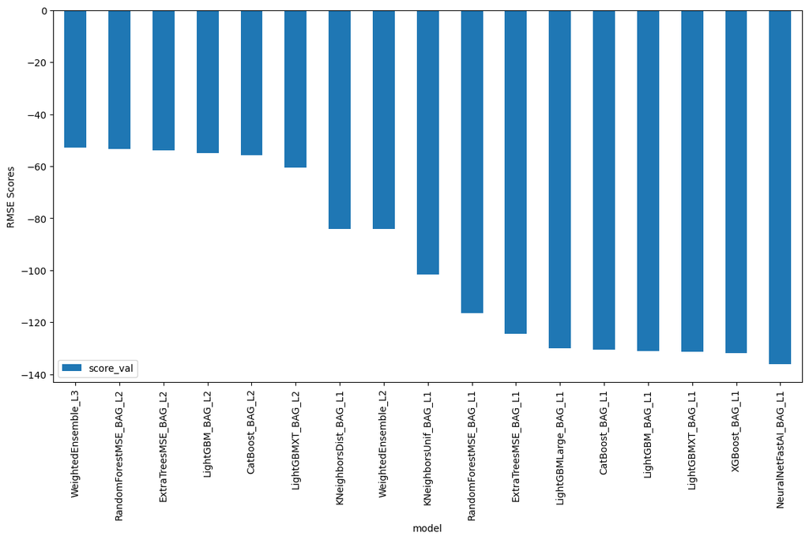

```python
# Output the model's `score_val` in a bar chart to compare performance
import matplotlib.pyplot as plt
leaderboard_df.plot(kind="bar", x="model", y="score_val", figsize=(14, 7))
plt.ylabel("RMSE Scores")
plt.show()
```

### Review AutoGluon's training run with ranking of models that did the best.

```python
predictor.fit_summary()
```

```
*** Summary of fit() ***
Estimated performance of each model:
                     model   score_val              eval_metric  pred_time_val    fit_time  pred_time_val_marginal  fit_time_marginal  stack_level  can_infer  fit_order
0      WeightedEnsemble_L3  -52.770755  root_mean_squared_error      12.400488  298.849899                0.000626           0.041975            3       True         17
1   RandomForestMSE_BAG_L2  -53.448208  root_mean_squared_error      11.497125  278.824567                0.620925          17.700490            2       True         14
2     ExtraTreesMSE_BAG_L2  -53.834030  root_mean_squared_error      11.483898  266.293839                0.607698           5.169762            2       True         16
3          LightGBM_BAG_L2  -54.855271  root_mean_squared_error      11.171240  275.937672                0.295040          14.813595            2       True         13
4          CatBoost_BAG_L2  -55.775931  root_mean_squared_error      10.930951  305.077667                0.054751          43.953591            2       True         15
5        LightGBMXT_BAG_L2  -60.463598  root_mean_squared_error      14.463200  291.124430                3.587000          30.000353            2       True         12
6    KNeighborsDist_BAG_L1  -84.135011  root_mean_squared_error       0.042935    0.018896                0.042935           0.018896            1       True          2
7      WeightedEnsemble_L2  -84.135011  root_mean_squared_error       0.043814    0.060308                0.000879           0.041412            2       True         11
8    KNeighborsUnif_BAG_L1 -101.561182  root_mean_squared_error       0.041703    0.162199                0.041703           0.162199            1       True          1
9   RandomForestMSE_BAG_L1 -116.548359  root_mean_squared_error       0.623815    6.105613                0.623815           6.105613            1       True          5
10    ExtraTreesMSE_BAG_L1 -124.600676  root_mean_squared_error       0.534851    2.976494                0.534851           2.976494            1       True          7
11    LightGBMLarge_BAG_L1 -130.035209  root_mean_squared_error       0.811838   18.166237                0.811838          18.166237            1       True         10
12         CatBoost_BAG_L1 -130.463410  root_mean_squared_error       0.103397  121.189203                0.103397         121.189203            1       True          6
13         LightGBM_BAG_L1 -131.054162  root_mean_squared_error       1.602350   16.052026                1.602350          16.052026            1       True          4
14       LightGBMXT_BAG_L1 -131.460909  root_mean_squared_error       6.308168   36.636003                6.308168          36.636003            1       True          3
15          XGBoost_BAG_L1 -131.893935  root_mean_squared_error       0.539536   10.743532                0.539536          10.743532            1       True          9
16  NeuralNetFastAI_BAG_L1 -136.161887  root_mean_squared_error       0.267607   49.073874                0.267607          49.073874            1       True          8
Number of models trained: 17
Types of models trained:
{'StackerEnsembleModel_NNFastAiTabular', 'StackerEnsembleModel_LGB', 'StackerEnsembleModel_KNN', 'StackerEnsembleModel_XGBoost', 'StackerEnsembleModel_XT', 'StackerEnsembleModel_CatBoost', 'WeightedEnsembleModel', 'StackerEnsembleModel_RF'}
Bagging used: True  (with 8 folds)
Multi-layer stack-ensembling used: True  (with 3 levels)
Feature Metadata (Processed):
(raw dtype, special dtypes):
('float', [])                : 3 | ['temp', 'atemp', 'windspeed']
('int', [])                  : 3 | ['season', 'weather', 'humidity']
('int', ['bool'])            : 2 | ['holiday', 'workingday']
('int', ['datetime_as_int']) : 5 | ['datetime', 'datetime.year', 'datetime.month', 'datetime.day', 'datetime.dayofweek']
*** End of fit() summary ***
```

[output not shown]

[output cut: 231 more lines]

[output not shown]

### Create predictions from test dataset

```python
predictions = predictor.predict(test)
predictions.head()
```

```
0    23.608799
1    42.166515
2    47.088707
3    49.836098
4    51.789837
Name: count, dtype: float32
```

#### NOTE: Kaggle will reject the submission if we don't set everything to be > 0.

```python
# Describe the `predictions` series to see if there are any negative values
predictions.describe()
```

```
count    6493.000000
mean      100.383469
std        89.757744
min         3.014769
25%        21.042934
50%        64.080925
75%       168.454651
max       361.620544
Name: count, dtype: float64
```

```python
# How many negative values do we have?
negative_pred_count = predictions.apply(lambda x: 1 if x<0 else 0)

pred_pos = (negative_pred_count==0).sum()
pred_neg = (negative_pred_count==1).sum()

print("Total predictions:", len(predictions.index))
print("Total positive prediction values :", pred_pos)
print("Total negative prediction values :", pred_neg)
```

```
Total predictions: 6493
Total positive prediction values : 6493
Total negative prediction values : 0
```

```python
# Set them to zero
predictions[predictions<0] = 0

# Rechecking, if no predictions are less than 0
negative_pred_count = predictions.apply(lambda x: 1 if x<0 else 0)
pred_neg_count = (negative_pred_count==1).sum()
print(f"No. of negative predictions: {pred_neg_count}")
```

```
No. of negative predictions: 0
```

### Set predictions to submission dataframe, save, and submit

```python
submission["count"] = predictions
submission.to_csv("submission.csv", index=False)
```

```python
import json
kaggle_username = "nikitasrajkapini"
kaggle_key = "68e14a16ef2144e4b42414c22c2d6ee5"

# Save API token the kaggle.json file
with open("kaggle.json", "w") as f:
    json.dump({"username": kaggle_username, "key": kaggle_key}, f)

# Step 2: Move it to ~/.kaggle and set correct permissions
!mkdir -p ~/.kaggle
!cp kaggle.json ~/.kaggle/
!chmod 600 ~/.kaggle/kaggle.json
```

```python
!kaggle competitions submit -c bike-sharing-demand -f submission.csv -m "first raw submission"
```

```
Successfully submitted to Bike Sharing Demand
```

#### View submission via the command line or in the web browser under the competition's page - `My Submissions`

```python
!kaggle competitions submissions -c bike-sharing-demand | tail -n +1 | head -n 6
```

```
fileName        date                        description           status                     publicScore  privateScore
--------------  --------------------------  --------------------  -------------------------  -----------  ------------
submission.csv  2025-05-14 16:54:51.447000  first raw submission  SubmissionStatus.COMPLETE  1.80448      1.80448
```

#### Initial score of 1.80448

## Step 4: Exploratory Data Analysis and Creating an additional feature

- Any additional feature will do, but a great suggestion would be to separate out the datetime into hour, day, or month parts.

[output not shown]

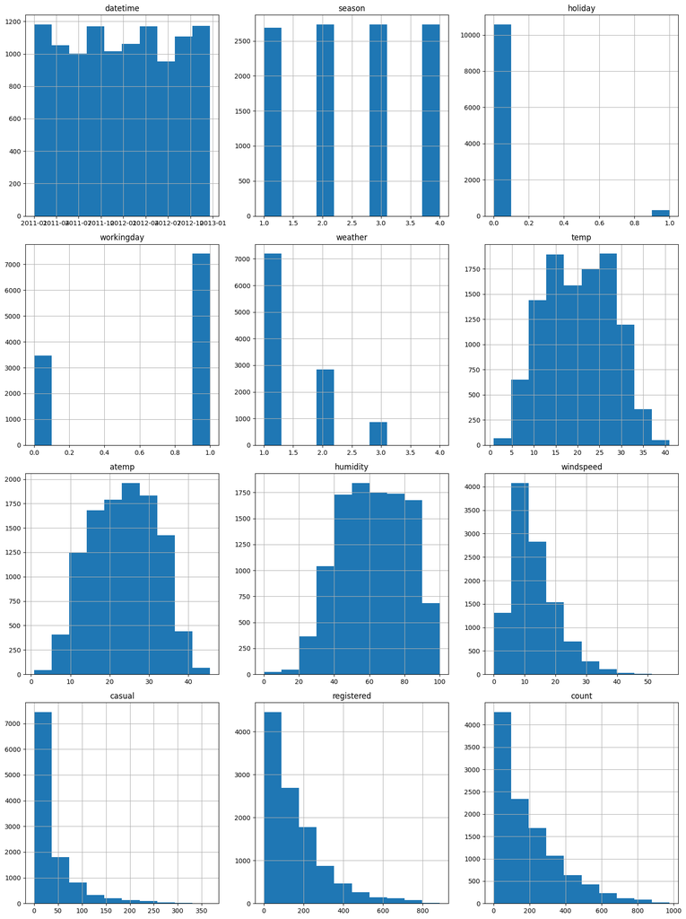

```python
# Create a histogram of all features to show the distribution of each one relative to the data. This is part of the exploritory data analysis
train.hist(figsize=(15,20))
plt.tight_layout()
plt.show()
```

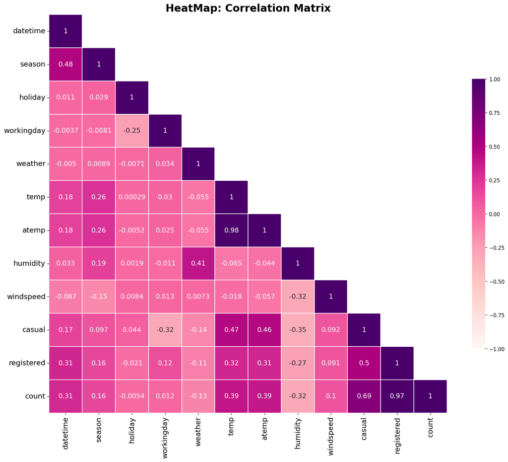

```python
#Plotting a heatmap to understand the correlation between the independent variables
import numpy as np
import matplotlib.pyplot as plt
import seaborn as sns
plt.figure(figsize = (15,15), dpi=120)
corr_data = train.copy()

corr_matrix = corr_data.corr()
f, ax_corr1 = plt.subplots(figsize=(15, 15), dpi=120)
# Create a mask to eliminate redundant repetitive correlations
corr_mask = np.array(corr_matrix)
corr_mask[np.tril_indices_from(corr_mask)] = False

# Plot heatmap using correlation matrix and mask
ax_corr1 = sns.heatmap(corr_matrix, cmap= 'RdPu', cbar_kws={"shrink": .5}, vmin= -1, vmax=1, center=0,
            square=True, mask=corr_mask, annot=True, linewidths=0.01, annot_kws={"size":13})
plt.xticks(fontsize=14, rotation=90)
plt.yticks(fontsize=14, rotation=0)
plt.title("HeatMap: Correlation Matrix", fontsize=20, fontweight='bold')
plt.tight_layout()
plt.autoscale()
plt.show()
```

```python
# Splitting the 'datetime' feature in train data
train["year"] = train["datetime"].dt.year
train["month"] = train["datetime"].dt.month
train["day"] = train["datetime"].dt.dayofweek  # Note: day -> dayofweek (0->Monday, 6->Sunday)
train["hour"] = train["datetime"].dt.hour
train.drop(["datetime"], axis=1, inplace=True)     # Drop 'datetime' feature
train.head()
```

|  | season | holiday | workingday | weather | temp | atemp | humidity | windspeed | casual | registered | count | year | month | day | hour |
| --- | --- | --- | --- | --- | --- | --- | --- | --- | --- | --- | --- | --- | --- | --- | --- |
| 0 | 1 | 0 | 0 | 1 | 9.84 | 14.395 | 81 | 0.0 | 3 | 13 | 16 | 2011 | 1 | 5 | 0 |
| 1 | 1 | 0 | 0 | 1 | 9.02 | 13.635 | 80 | 0.0 | 8 | 32 | 40 | 2011 | 1 | 5 | 1 |
| 2 | 1 | 0 | 0 | 1 | 9.02 | 13.635 | 80 | 0.0 | 5 | 27 | 32 | 2011 | 1 | 5 | 2 |
| 3 | 1 | 0 | 0 | 1 | 9.84 | 14.395 | 75 | 0.0 | 3 | 10 | 13 | 2011 | 1 | 5 | 3 |
| 4 | 1 | 0 | 0 | 1 | 9.84 | 14.395 | 75 | 0.0 | 0 | 1 | 1 | 2011 | 1 | 5 | 4 |

```python
# Splitting the 'datetime' feature in test data
test["year"] = test["datetime"].dt.year
test["month"] = test["datetime"].dt.month
test["day"] = test["datetime"].dt.dayofweek  # Note: day -> dayofweek (0->Monday, 6->Sunday)
test["hour"] = test["datetime"].dt.hour
test.drop(["datetime"], axis=1, inplace=True)   # Drop 'datetime' feature
test.head()
```

|  | season | holiday | workingday | weather | temp | atemp | humidity | windspeed | year | month | day | hour |
| --- | --- | --- | --- | --- | --- | --- | --- | --- | --- | --- | --- | --- |
| 0 | 1 | 0 | 1 | 1 | 10.66 | 11.365 | 56 | 26.0027 | 2011 | 1 | 3 | 0 |
| 1 | 1 | 0 | 1 | 1 | 10.66 | 13.635 | 56 | 0.0000 | 2011 | 1 | 3 | 1 |
| 2 | 1 | 0 | 1 | 1 | 10.66 | 13.635 | 56 | 0.0000 | 2011 | 1 | 3 | 2 |
| 3 | 1 | 0 | 1 | 1 | 10.66 | 12.880 | 56 | 11.0014 | 2011 | 1 | 3 | 3 |
| 4 | 1 | 0 | 1 | 1 | 10.66 | 12.880 | 56 | 11.0014 | 2011 | 1 | 3 | 4 |

```python
# Recheck datatype of features in the train dataset
train.info()
```

```
<class 'pandas.core.frame.DataFrame'>
RangeIndex: 10886 entries, 0 to 10885
Data columns (total 15 columns):
 #   Column      Non-Null Count  Dtype
---  ------      --------------  -----
 0   season      10886 non-null  int64
 1   holiday     10886 non-null  int64
 2   workingday  10886 non-null  int64
 3   weather     10886 non-null  int64
 4   temp        10886 non-null  float64
 5   atemp       10886 non-null  float64
 6   humidity    10886 non-null  int64
 7   windspeed   10886 non-null  float64
 8   casual      10886 non-null  int64
 9   registered  10886 non-null  int64
 10  count       10886 non-null  int64
 11  year        10886 non-null  int32
 12  month       10886 non-null  int32
 13  day         10886 non-null  int32
 14  hour        10886 non-null  int32
dtypes: float64(3), int32(4), int64(8)
memory usage: 1.1 MB
```

**Make category types for these so models know they are not just numbers**

- AutoGluon originally sees these as ints, but in reality they are int representations of a category.
- Setting the dtype to category will classify these as categories in AutoGluon.

```python
# Convert 'int' feature columns that are categorical in nature to 'category' type
train["season"] = train["season"].astype("category")
train["weather"] = train["weather"].astype("category")

test["season"] = test["season"].astype("category")
test["weather"] = test["weather"].astype("category")
```

```python
train.head()
```

|  | season | holiday | workingday | weather | temp | atemp | humidity | windspeed | casual | registered | count | year | month | day | hour |
| --- | --- | --- | --- | --- | --- | --- | --- | --- | --- | --- | --- | --- | --- | --- | --- |
| 0 | 1 | 0 | 0 | 1 | 9.84 | 14.395 | 81 | 0.0 | 3 | 13 | 16 | 2011 | 1 | 5 | 0 |
| 1 | 1 | 0 | 0 | 1 | 9.02 | 13.635 | 80 | 0.0 | 8 | 32 | 40 | 2011 | 1 | 5 | 1 |
| 2 | 1 | 0 | 0 | 1 | 9.02 | 13.635 | 80 | 0.0 | 5 | 27 | 32 | 2011 | 1 | 5 | 2 |
| 3 | 1 | 0 | 0 | 1 | 9.84 | 14.395 | 75 | 0.0 | 3 | 10 | 13 | 2011 | 1 | 5 | 3 |
| 4 | 1 | 0 | 0 | 1 | 9.84 | 14.395 | 75 | 0.0 | 0 | 1 | 1 | 2011 | 1 | 5 | 4 |

```python
train.info()
```

```
<class 'pandas.core.frame.DataFrame'>
RangeIndex: 10886 entries, 0 to 10885
Data columns (total 15 columns):
 #   Column      Non-Null Count  Dtype
---  ------      --------------  -----
 0   season      10886 non-null  category
 1   holiday     10886 non-null  int64
 2   workingday  10886 non-null  int64
 3   weather     10886 non-null  category
 4   temp        10886 non-null  float64
 5   atemp       10886 non-null  float64
 6   humidity    10886 non-null  int64
 7   windspeed   10886 non-null  float64
 8   casual      10886 non-null  int64
 9   registered  10886 non-null  int64
 10  count       10886 non-null  int64
 11  year        10886 non-null  int32
 12  month       10886 non-null  int32
 13  day         10886 non-null  int32
 14  hour        10886 non-null  int32
dtypes: category(2), float64(3), int32(4), int64(6)
memory usage: 957.3 KB
```

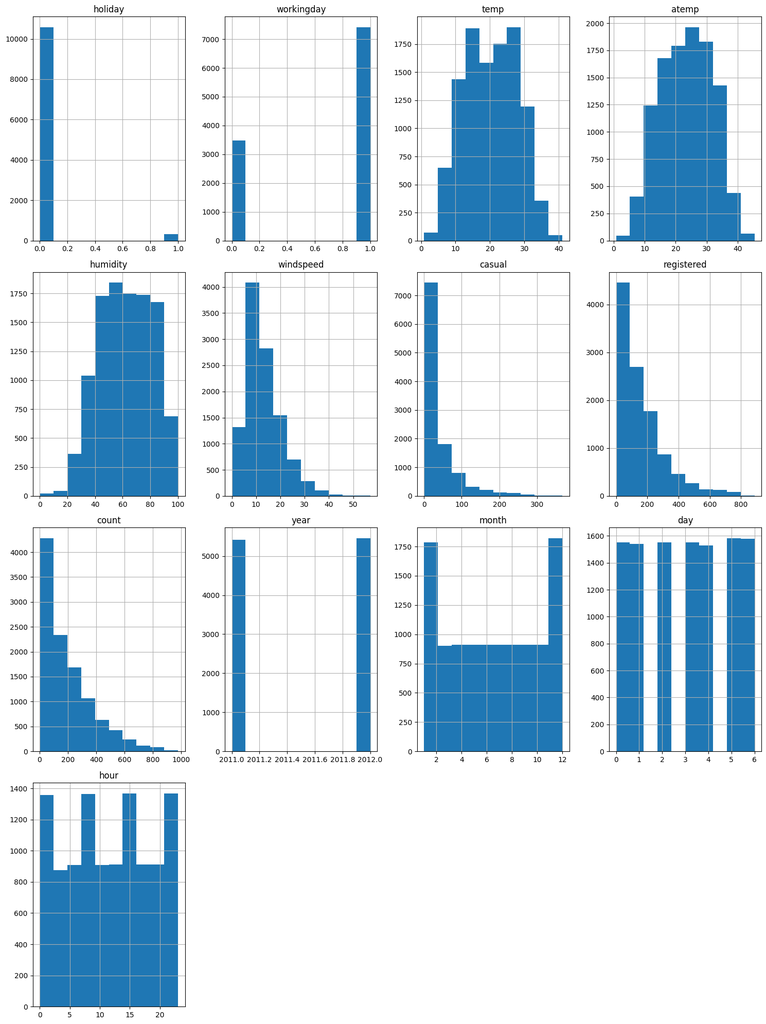

```python
# View histogram of all features again now with the hour feature
train.hist(figsize=(15,20))  # Note: 'casual' and 'registered' are ignored during training as they are absent in test data

plt.tight_layout()
plt.show()
```

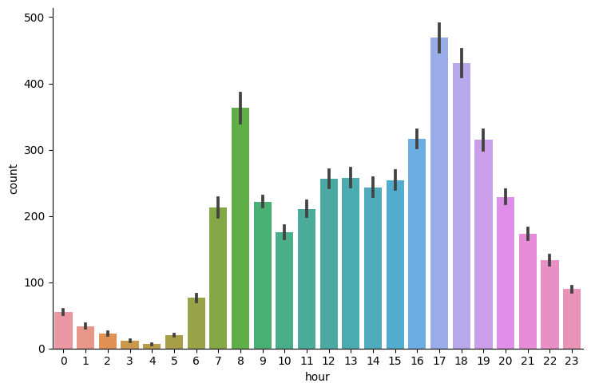

```python
# Variation in`count` w.r.t `hour`

# Using catplot: 'kind':bar makes sure to take value of 'count' for every record into account
sns.catplot(x="hour",y="count",data=train,kind='bar',height=5,aspect=1.5)
plt.tight_layout()
plt.show()
```

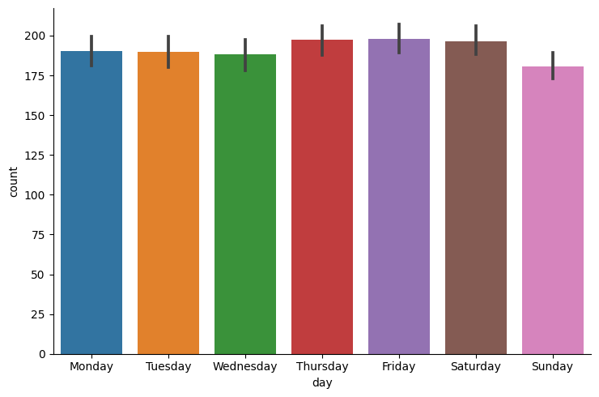

```python
# Variation in`count` w.r.t `day` (dayofweek) [0: Monday -> 6: Sunday]

# Using catplot: 'kind':bar makes sure to take value of 'count' for every record into account
sns.catplot(x="day",y="count",data=train,kind='bar',height=5,aspect=1.5)
plt.tight_layout()
plt.xticks(ticks=range(0,7), labels=["Monday", "Tuesday", "Wednesday",
                                     "Thursday", "Friday", "Saturday", "Sunday"])
plt.show()
```

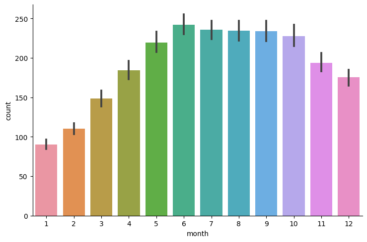

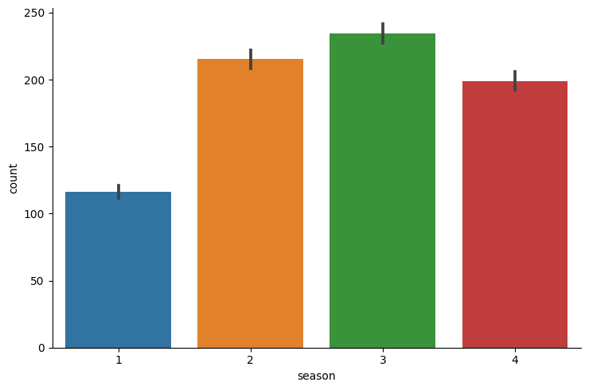

```python
# Variation in`count` w.r.t `month` and 'season'

# Using catplot: 'kind':bar makes sure to take value of 'count' for every record into account
sns.catplot(x="month",y="count",data=train,kind='bar',height=5,aspect=1.5)
sns.catplot(x="season",y="count",data=train,kind='bar',height=5,aspect=1.5)
plt.tight_layout()
plt.show()
```

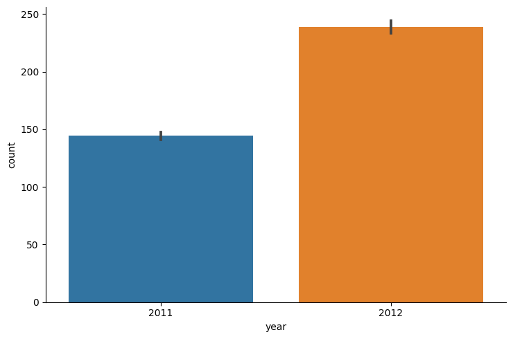

```python
# Variation in`count` w.r.t `year`

# Using catplot: 'kind':bar makes sure to take value of 'count' for every record into account
sns.catplot(x="year",y="count",data=train,kind='bar',height=5,aspect=1.5)
plt.tight_layout()
plt.show()
```

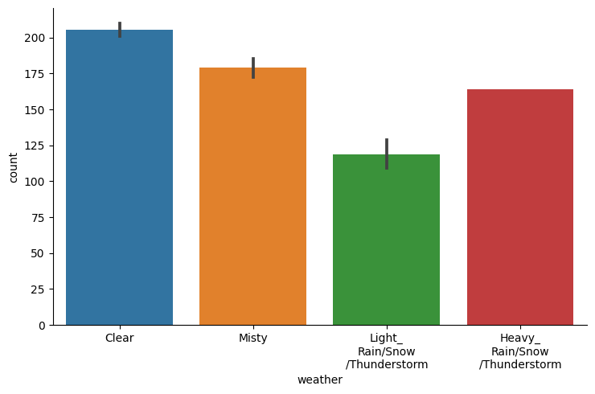

```python
# Variation in`count` w.r.t `weather'

# Using catplot: 'kind':bar makes sure to take value of 'count' for every record into account
sns.catplot(x="weather",y="count",data=train,kind='bar',height=5,aspect=1.5)
plt.xticks(ticks=range(0,4), labels=["Clear","Misty",
                                     "Light_\nRain/Snow\n/Thunderstorm",
                                     "Heavy_\nRain/Snow\n/Thunderstorm"])
plt.tight_layout()
plt.show()
```

```python
# New feature 'day_type' contains categories 'weekend', 'weekday', or 'holiday' (In Train and Test set)

# Adding features - 'day_type' in train data
train["day_type"]=""
train.loc[(train.holiday==1),"day_type"] = "holiday"
train.loc[((train.holiday==0) & (train.workingday==1)), "day_type"] = "weekday"
train.loc[((train.holiday==0) & (train.workingday==0)), "day_type"] = "weekend"

# Adding features - 'day_type' in test data
test["day_type"]=""
test.loc[(test.holiday==1),"day_type"] = "holiday"
test.loc[((test.holiday==0) & (test.workingday==1)), "day_type"] = "weekday"
test.loc[((test.holiday==0) & (test.workingday==0)), "day_type"] = "weekend"

# Change the datatype to category
train["day_type"] = train["day_type"].astype("category")
test["day_type"] = test["day_type"].astype("category")

train.head()
```

|  | season | holiday | workingday | weather | temp | atemp | humidity | windspeed | casual | registered | count | year | month | day | hour | day_type |
| --- | --- | --- | --- | --- | --- | --- | --- | --- | --- | --- | --- | --- | --- | --- | --- | --- |
| 0 | 1 | 0 | 0 | 1 | 9.84 | 14.395 | 81 | 0.0 | 3 | 13 | 16 | 2011 | 1 | 5 | 0 | weekend |
| 1 | 1 | 0 | 0 | 1 | 9.02 | 13.635 | 80 | 0.0 | 8 | 32 | 40 | 2011 | 1 | 5 | 1 | weekend |
| 2 | 1 | 0 | 0 | 1 | 9.02 | 13.635 | 80 | 0.0 | 5 | 27 | 32 | 2011 | 1 | 5 | 2 | weekend |
| 3 | 1 | 0 | 0 | 1 | 9.84 | 14.395 | 75 | 0.0 | 3 | 10 | 13 | 2011 | 1 | 5 | 3 | weekend |
| 4 | 1 | 0 | 0 | 1 | 9.84 | 14.395 | 75 | 0.0 | 0 | 1 | 1 | 2011 | 1 | 5 | 4 | weekend |

```python
train.describe()
```

|  | holiday | workingday | temp | atemp | humidity | windspeed | casual | registered | count | year | month | day | hour |
| --- | --- | --- | --- | --- | --- | --- | --- | --- | --- | --- | --- | --- | --- |
| count | 10886.000000 | 10886.000000 | 10886.00000 | 10886.000000 | 10886.000000 | 10886.000000 | 10886.000000 | 10886.000000 | 10886.000000 | 10886.000000 | 10886.000000 | 10886.000000 | 10886.000000 |
| mean | 0.028569 | 0.680875 | 20.23086 | 23.655084 | 61.886460 | 12.799395 | 36.021955 | 155.552177 | 191.574132 | 2011.501929 | 6.521495 | 3.013963 | 11.541613 |
| std | 0.166599 | 0.466159 | 7.79159 | 8.474601 | 19.245033 | 8.164537 | 49.960477 | 151.039033 | 181.144454 | 0.500019 | 3.444373 | 2.004585 | 6.915838 |
| min | 0.000000 | 0.000000 | 0.82000 | 0.760000 | 0.000000 | 0.000000 | 0.000000 | 0.000000 | 1.000000 | 2011.000000 | 1.000000 | 0.000000 | 0.000000 |
| 25% | 0.000000 | 0.000000 | 13.94000 | 16.665000 | 47.000000 | 7.001500 | 4.000000 | 36.000000 | 42.000000 | 2011.000000 | 4.000000 | 1.000000 | 6.000000 |
| 50% | 0.000000 | 1.000000 | 20.50000 | 24.240000 | 62.000000 | 12.998000 | 17.000000 | 118.000000 | 145.000000 | 2012.000000 | 7.000000 | 3.000000 | 12.000000 |
| 75% | 0.000000 | 1.000000 | 26.24000 | 31.060000 | 77.000000 | 16.997900 | 49.000000 | 222.000000 | 284.000000 | 2012.000000 | 10.000000 | 5.000000 | 18.000000 |
| max | 1.000000 | 1.000000 | 41.00000 | 45.455000 | 100.000000 | 56.996900 | 367.000000 | 886.000000 | 977.000000 | 2012.000000 | 12.000000 | 6.000000 | 23.000000 |

```python
# Dropping highly correlated independent feature 'atemp' from train and test datasets
train.drop(["atemp"], axis=1, inplace=True)
test.drop(["atemp"], axis=1, inplace=True)

# Checking datatypes of variables
train.info()
```

```
<class 'pandas.core.frame.DataFrame'>
RangeIndex: 10886 entries, 0 to 10885
Data columns (total 15 columns):
 #   Column      Non-Null Count  Dtype
---  ------      --------------  -----
 0   season      10886 non-null  category
 1   holiday     10886 non-null  int64
 2   workingday  10886 non-null  int64
 3   weather     10886 non-null  category
 4   temp        10886 non-null  float64
 5   humidity    10886 non-null  int64
 6   windspeed   10886 non-null  float64
 7   casual      10886 non-null  int64
 8   registered  10886 non-null  int64
 9   count       10886 non-null  int64
 10  year        10886 non-null  int32
 11  month       10886 non-null  int32
 12  day         10886 non-null  int32
 13  hour        10886 non-null  int32
 14  day_type    10886 non-null  category
dtypes: category(3), float64(2), int32(4), int64(6)
memory usage: 883.0 KB
```

```python
print("(After EDA + Feature Engineering) Train Data Shape : ", train.shape)
print("(After EDA + Feature Engineering) Test Data Shape  : ", test.shape)
```

```
(After EDA + Feature Engineering) Train Data Shape :  (10886, 15)
(After EDA + Feature Engineering) Test Data Shape  :  (6493, 12)
```

## Step 5: Rerun the model with the same settings as before, just with more features

```python
# Requirements: (Same settings as that of initial run) For AutoGluon's Tabular Predictions
eval_metric = 'root_mean_squared_error'
label = 'count'
ignored_columns = ["casual", "registered"]   # Ignored columns while training
train_data = train                           # 'casual' and 'registered' columns are already dropped/ignored
time_limit = 600                             # 10 minutes -> 60*10 = 600 seconds
presets = "best_quality"                     # auto_stack=True
```

```python
predictor_new_features = TabularPredictor(label=label,
                                          problem_type= 'regression',
                                          eval_metric=eval_metric,
                                          learner_kwargs={'ignored_columns': ignored_columns}).fit(
                                                                                           train_data = train_data,excluded_model_types=["XGBoost"],
                                                                                           time_limit=time_limit,
                                                                                           presets=presets)
```

```
No path specified. Models will be saved in: "AutogluonModels/ag-20250514_171121"
Verbosity: 2 (Standard Logging)
=================== System Info ===================
AutoGluon Version:  1.3.0
Python Version:     3.11.11
Operating System:   Linux
Platform Machine:   x86_64
Platform Version:   #1 SMP PREEMPT_DYNAMIC Sun Nov 10 10:07:59 UTC 2024
CPU Count:          4
Memory Avail:       28.93 GB / 31.35 GB (92.3%)
Disk Space Avail:   13.08 GB / 19.52 GB (67.0%)
===================================================
Presets specified: ['best_quality']
Setting dynamic_stacking from 'auto' to True. Reason: Enable dynamic_stacking when use_bag_holdout is disabled. (use_bag_holdout=False)
Stack configuration (auto_stack=True): num_stack_levels=1, num_bag_folds=8, num_bag_sets=1
DyStack is enabled (dynamic_stacking=True). AutoGluon will try to determine whether the input data is affected by stacked overfitting and enable or disable stacking as a consequence.
	This is used to identify the optimal `num_stack_levels` value. Copies of AutoGluon will be fit on subsets of the data. Then holdout validation data is used to detect stacked overfitting.
	Running DyStack for up to 150s of the 600s of remaining time (25%).
		Context path: "/kaggle/working/AutogluonModels/ag-20250514_171121/ds_sub_fit/sub_fit_ho"
Leaderboard on holdout data (DyStack):
                     model  score_holdout   score_val              eval_metric  pred_time_test  pred_time_val    fit_time  pred_time_test_marginal  pred_time_val_marginal  fit_time_marginal  stack_level  can_infer  fit_order
0      WeightedEnsemble_L3     -33.582998  -35.113859  root_mean_squared_error       10.734948      11.894129  127.232706                 0.003717                0.000558           0.020344            3       True         11
1      WeightedEnsemble_L2     -33.802774  -35.170356  root_mean_squared_error        9.972713      10.481228   87.722694                 0.002738                0.000556           0.017205            2       True          7
2          LightGBM_BAG_L2     -33.838749  -35.813003  root_mean_squared_error       10.053996      10.680326  100.182744                 0.067851                0.107395          12.319090            2       True          9
3        LightGBMXT_BAG_L2     -33.897544  -35.986634  root_mean_squared_error       10.197965      11.215025  102.722117                 0.211819                0.642094          14.858464            2       True          8
4          LightGBM_BAG_L1     -34.077597  -36.618972  root_mean_squared_error        1.133319       2.186393   18.471417                 1.133319                2.186393          18.471417            1       True          4
5   RandomForestMSE_BAG_L2     -34.506753  -35.752971  root_mean_squared_error       10.451561      11.144083  100.034808                 0.465415                0.571152          12.171154            2       True         10
6        LightGBMXT_BAG_L1     -35.344986  -37.292819  root_mean_squared_error        8.026288       7.645852   42.873730                 8.026288                7.645852          42.873730            1       True          3
7          CatBoost_BAG_L1     -39.850103  -40.733068  root_mean_squared_error        0.352723       0.087590   21.371684                 0.352723                0.087590          21.371684            1       True          6
8   RandomForestMSE_BAG_L1     -40.224471  -40.569445  root_mean_squared_error        0.457646       0.560837    4.988658                 0.457646                0.560837           4.988658            1       True          5
9    KNeighborsDist_BAG_L1    -112.558141 -111.555688  root_mean_squared_error        0.007728       0.045873    0.008207                 0.007728                0.045873           0.008207            1       True          2
10   KNeighborsUnif_BAG_L1    -115.190574 -114.884849  root_mean_squared_error        0.008442       0.046386    0.149958                 0.008442                0.046386           0.149958            1       True          1
	1	 = Optimal   num_stack_levels (Stacked Overfitting Occurred: False)
	165s	 = DyStack   runtime |	435s	 = Remaining runtime
Starting main fit with num_stack_levels=1.
	For future fit calls on this dataset, you can skip DyStack to save time: `predictor.fit(..., dynamic_stacking=False, num_stack_levels=1)`
Beginning AutoGluon training ... Time limit = 435s
AutoGluon will save models to "/kaggle/working/AutogluonModels/ag-20250514_171121"
Train Data Rows:    10886
Train Data Columns: 14
```

[output cut: 116 more lines]

```
	-34.3061	 = Validation score   (-root_mean_squared_error)
	4.63s	 = Training   runtime
	0.65s	 = Validation runtime
Fitting model: NeuralNetFastAI_BAG_L2 ... Training model for up to 30.23s of the 30.18s of remaining time.
	Fitting 8 child models (S1F1 - S1F8) | Fitting with ParallelLocalFoldFittingStrategy (4 workers, per: cpus=1, gpus=0, memory=0.03%)
	-34.5881	 = Validation score   (-root_mean_squared_error)
	38.81s	 = Training   runtime
	0.34s	 = Validation runtime
Fitting model: WeightedEnsemble_L3 ... Training model for up to 360.00s of the -12.46s of remaining time.
	Ensemble Weights: {'CatBoost_BAG_L2': 0.316, 'ExtraTreesMSE_BAG_L2': 0.316, 'LightGBMXT_BAG_L1': 0.105, 'LightGBM_BAG_L1': 0.105, 'CatBoost_BAG_L1': 0.105, 'NeuralNetFastAI_BAG_L2': 0.053}
	-33.8687	 = Validation score   (-root_mean_squared_error)
	0.06s	 = Training   runtime
	0.0s	 = Validation runtime
AutoGluon training complete, total runtime = 447.5s ... Best model: WeightedEnsemble_L3 | Estimated inference throughput: 97.2 rows/s (1361 batch size)
TabularPredictor saved. To load, use: predictor = TabularPredictor.load("/kaggle/working/AutogluonModels/ag-20250514_171121")
```

```python
predictor_new_features.fit_summary()
```

```
*** Summary of fit() ***
Estimated performance of each model:
                     model   score_val              eval_metric  pred_time_val    fit_time  pred_time_val_marginal  fit_time_marginal  stack_level  can_infer  fit_order
0      WeightedEnsemble_L3  -33.868672  root_mean_squared_error      15.693847  368.486356                0.000933           0.055698            3       True         16
1      WeightedEnsemble_L2  -34.158085  root_mean_squared_error      13.999630  245.611120                0.000932           0.039478            2       True          9
2          CatBoost_BAG_L2  -34.224114  root_mean_squared_error      14.712371  324.990603                0.084979          41.112384            2       True         13
3     ExtraTreesMSE_BAG_L2  -34.306143  root_mean_squared_error      15.272872  288.506309                0.645480           4.628090            2       True         14
4   NeuralNetFastAI_BAG_L2  -34.588069  root_mean_squared_error      14.962456  322.690184                0.335064          38.811965            2       True         15
5          LightGBM_BAG_L2  -34.741722  root_mean_squared_error      14.794035  296.382012                0.166643          12.503793            2       True         11
6   RandomForestMSE_BAG_L2  -35.088291  root_mean_squared_error      15.239616  299.597060                0.612224          15.718841            2       True         12
7        LightGBMXT_BAG_L2  -35.177877  root_mean_squared_error      15.026946  298.067597                0.399554          14.189378            2       True         10
8          CatBoost_BAG_L1  -35.603019  root_mean_squared_error       0.293597  172.227868                0.293597         172.227868            1       True          6
9          LightGBM_BAG_L1  -35.780355  root_mean_squared_error       3.154888   22.382504                3.154888          22.382504            1       True          4
10       LightGBMXT_BAG_L1  -36.708020  root_mean_squared_error       9.409753   42.541512                9.409753          42.541512            1       True          3
11    ExtraTreesMSE_BAG_L1  -38.580226  root_mean_squared_error       0.580339    2.963726                0.580339           2.963726            1       True          7
12  RandomForestMSE_BAG_L1  -39.717239  root_mean_squared_error       0.560122    5.456032                0.560122           5.456032            1       True          5
13  NeuralNetFastAI_BAG_L1  -52.510416  root_mean_squared_error       0.489491   38.276123                0.489491          38.276123            1       True          8
14   KNeighborsDist_BAG_L1 -109.992433  root_mean_squared_error       0.076075    0.014789                0.076075           0.014789            1       True          2
15   KNeighborsUnif_BAG_L1 -113.413646  root_mean_squared_error       0.063127    0.015666                0.063127           0.015666            1       True          1
Number of models trained: 16
Types of models trained:
{'StackerEnsembleModel_NNFastAiTabular', 'StackerEnsembleModel_LGB', 'StackerEnsembleModel_KNN', 'StackerEnsembleModel_XT', 'StackerEnsembleModel_CatBoost', 'WeightedEnsembleModel', 'StackerEnsembleModel_RF'}
Bagging used: True  (with 8 folds)
Multi-layer stack-ensembling used: True  (with 3 levels)
Feature Metadata (Processed):
(raw dtype, special dtypes):
('category', [])  : 3 | ['season', 'weather', 'day_type']
('float', [])     : 2 | ['temp', 'windspeed']
('int', [])       : 4 | ['humidity', 'month', 'day', 'hour']
('int', ['bool']) : 3 | ['holiday', 'workingday', 'year']
*** End of fit() summary ***
```

[output not shown]

[output cut: 215 more lines]

[output not shown]

```python
# Leaderboard dataframe
leaderboard_new_features_df = pd.DataFrame(predictor_new_features.leaderboard(silent=True))
leaderboard_new_features_df
```

|  | model | score_val | eval_metric | pred_time_val | fit_time | pred_time_val_marginal | fit_time_marginal | stack_level | can_infer | fit_order |
| --- | --- | --- | --- | --- | --- | --- | --- | --- | --- | --- |
| 0 | WeightedEnsemble_L3 | -33.868672 | root_mean_squared_error | 15.693847 | 368.486356 | 0.000933 | 0.055698 | 3 | True | 16 |
| 1 | WeightedEnsemble_L2 | -34.158085 | root_mean_squared_error | 13.999630 | 245.611120 | 0.000932 | 0.039478 | 2 | True | 9 |
| 2 | CatBoost_BAG_L2 | -34.224114 | root_mean_squared_error | 14.712371 | 324.990603 | 0.084979 | 41.112384 | 2 | True | 13 |
| 3 | ExtraTreesMSE_BAG_L2 | -34.306143 | root_mean_squared_error | 15.272872 | 288.506309 | 0.645480 | 4.628090 | 2 | True | 14 |
| 4 | NeuralNetFastAI_BAG_L2 | -34.588069 | root_mean_squared_error | 14.962456 | 322.690184 | 0.335064 | 38.811965 | 2 | True | 15 |
| 5 | LightGBM_BAG_L2 | -34.741722 | root_mean_squared_error | 14.794035 | 296.382012 | 0.166643 | 12.503793 | 2 | True | 11 |
| 6 | RandomForestMSE_BAG_L2 | -35.088291 | root_mean_squared_error | 15.239616 | 299.597060 | 0.612224 | 15.718841 | 2 | True | 12 |
| 7 | LightGBMXT_BAG_L2 | -35.177877 | root_mean_squared_error | 15.026946 | 298.067597 | 0.399554 | 14.189378 | 2 | True | 10 |
| 8 | CatBoost_BAG_L1 | -35.603019 | root_mean_squared_error | 0.293597 | 172.227868 | 0.293597 | 172.227868 | 1 | True | 6 |
| 9 | LightGBM_BAG_L1 | -35.780355 | root_mean_squared_error | 3.154888 | 22.382504 | 3.154888 | 22.382504 | 1 | True | 4 |
| 10 | LightGBMXT_BAG_L1 | -36.708020 | root_mean_squared_error | 9.409753 | 42.541512 | 9.409753 | 42.541512 | 1 | True | 3 |
| 11 | ExtraTreesMSE_BAG_L1 | -38.580226 | root_mean_squared_error | 0.580339 | 2.963726 | 0.580339 | 2.963726 | 1 | True | 7 |
| 12 | RandomForestMSE_BAG_L1 | -39.717239 | root_mean_squared_error | 0.560122 | 5.456032 | 0.560122 | 5.456032 | 1 | True | 5 |
| 13 | NeuralNetFastAI_BAG_L1 | -52.510416 | root_mean_squared_error | 0.489491 | 38.276123 | 0.489491 | 38.276123 | 1 | True | 8 |
| 14 | KNeighborsDist_BAG_L1 | -109.992433 | root_mean_squared_error | 0.076075 | 0.014789 | 0.076075 | 0.014789 | 1 | True | 2 |
| 15 | KNeighborsUnif_BAG_L1 | -113.413646 | root_mean_squared_error | 0.063127 | 0.015666 | 0.063127 | 0.015666 | 1 | True | 1 |

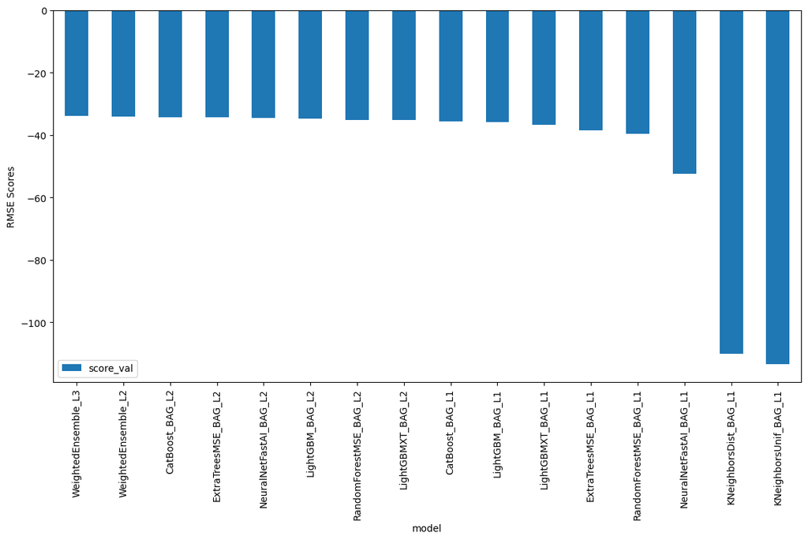

```python
# Output the model's `score_val` in a bar chart to compare performance
leaderboard_new_features_df.plot(kind="bar", x="model", y="score_val", figsize=(14, 7))
plt.ylabel("RMSE Scores")
plt.show()
```

```python
predictions_new_features = predictor_new_features.predict(test)
predictions_new_features.head()
```

```
0    13.418136
1     5.711578
2     3.736376
3     2.772846
4     2.759018
Name: count, dtype: float32
```

```python
# Describe the `predictions_new_features` series to see if there are any negative values
predictions_new_features.describe()
```

```
count    6493.000000
mean      189.899551
std       174.788742
min        -6.642920
25%        44.238110
50%       147.532745
75%       281.334595
max       910.796631
Name: count, dtype: float64
```

```python
# How many negative values do we have?

# Rechecking the predictions in predictions_new_features
negative_pred_count = predictions_new_features.apply(lambda x: 1 if x<0 else 0)

pred_pos_count = (negative_pred_count==0).sum()
pred_neg_count = (negative_pred_count==1).sum()

print("Total predictions                :", len(predictions_new_features.index))
print("Total positive prediction values :", pred_pos_count)
print("Total negative prediction values :", pred_neg_count)
```

```
Total predictions                : 6493
Total positive prediction values : 6478
Total negative prediction values : 15
```

```python
# Remember to set all negative values to zero
predictions_new_features[predictions_new_features<0] = 0    # (In case, if negative values exist in the predictions_new_features, set them to 0)

# Rechecking, if no predictions are less than 0
negative_pred_count = predictions_new_features.apply(lambda x: 1 if x<0 else 0)
pred_neg_count = (negative_pred_count==1).sum()
print(f"No. of negative predictions: {pred_neg_count}")
```

```
No. of negative predictions: 0
```

```python
# Same thing as train and test dataset
submission_new_features = pd.read_csv('/kaggle/input/bike-sharing-demand/sampleSubmission.csv', parse_dates = ['datetime'])
submission_new_features.head()
```

|  | datetime | count |
| --- | --- | --- |
| 0 | 2011-01-20 00:00:00 | 0 |
| 1 | 2011-01-20 01:00:00 | 0 |
| 2 | 2011-01-20 02:00:00 | 0 |
| 3 | 2011-01-20 03:00:00 | 0 |
| 4 | 2011-01-20 04:00:00 | 0 |

```python
# Same submitting predictions
submission_new_features["count"] = predictions_new_features
submission_new_features.to_csv("submission_new_features.csv", index=False)
```

```python
!kaggle competitions submit -c bike-sharing-demand -f submission_new_features.csv -m "new features"
```

```
Successfully submitted to Bike Sharing Demand
```

```python
!kaggle competitions submissions -c bike-sharing-demand | tail -n +1 | head -n 6
```

```
fileName                     date                        description           status                     publicScore  privateScore
---------------------------  --------------------------  --------------------  -------------------------  -----------  ------------
submission_new_features.csv  2025-05-14 17:26:54.290000  new features          SubmissionStatus.COMPLETE  0.46797      0.46797
submission.csv               2025-05-14 16:54:51.447000  first raw submission  SubmissionStatus.COMPLETE  1.80448      1.80448
```

#### New Score of 0.46797

## Step 6: Hyper parameter optimization

- There are many options for hyper parameter optimization.
- Options are to change the AutoGluon higher level parameters or the individual model hyperparameters.
- The hyperparameters of the models themselves that are in AutoGluon. Those need the `hyperparameter` and `hyperparameter_tune_kwargs` arguments.

```python
# Requirements: (Same settings as initial run) For AutoGluon's Tabular Predictions
eval_metric = 'root_mean_squared_error'
label = 'count'
ignored_columns = ["casual", "registered"]   # Ignored columns while training
train_data = train                           # 'casual' and 'registered' columns are already dropped/ignored
time_limit = 600                             # 10 minutes -> 60*10 = 600 seconds
presets = "optimize_for_deployment"
```

```python
from autogluon.tabular import TabularPredictor
from autogluon.common.space import Real, Int, Categorical

# Define NN search space
nn_options = {
    'num_epochs': 5,
    'learning_rate': Real(1e-4, 1e-2, default=5e-4, log=True),
    'activation': Categorical('relu', 'softrelu', 'tanh'),
    'dropout_prob': Real(0.0, 0.5, default=0.1)
}

# Define GBM options
gbm_options = [
    {
        'extra_trees': True,
        'num_boost_round': Int(100, 500, default=100),
        'num_leaves': Int(25, 64, default=36),
        'ag_args': {'name_suffix': 'XT'}
    },
    {},  # default
    {
        "learning_rate": 0.03,
        "num_leaves": 128,
        "feature_fraction": 0.9,
        "min_data_in_leaf": 3,
        "ag_args": {
            "name_suffix": "Large",
            "priority": 0,
            "hyperparameter_tune_kwargs": None
        }
    }
]

# Combine into full hyperparameter dict
hyperparameters = {
    'GBM': gbm_options,
    'NN_TORCH': nn_options
}

# HPO setup
num_trials = 20
search_strategy = 'auto'
scheduler = 'local'

hyperparameter_tune_kwargs = {
    'num_trials': num_trials,
    'scheduler': scheduler,
    'searcher': search_strategy
}

# Fit the model
predictor_new_hpo = TabularPredictor(
    label='count',
    problem_type='regression',
    eval_metric='root_mean_squared_error',
    learner_kwargs={'ignored_columns': ignored_columns}
).fit(
    train_data=train,
    time_limit=time_limit,
    presets=presets,
    hyperparameters=hyperparameters,
    hyperparameter_tune_kwargs=hyperparameter_tune_kwargs,
    refit_full='best'
)
```

[output not shown]

[output cut: 36 more lines]

[output not shown]

```python
predictor_new_hpo.fit_summary()
```

```
*** Summary of fit() ***
Estimated performance of each model:
                 model  score_val              eval_metric  pred_time_val   fit_time  pred_time_val_marginal  fit_time_marginal  stack_level  can_infer  fit_order
0  WeightedEnsemble_L2 -37.746321  root_mean_squared_error       1.639189  22.626029                0.000470           0.007462            2       True          3
1         LightGBM/T16 -37.844296  root_mean_squared_error       0.910881  11.854667                0.910881          11.854667            1       True          1
2         LightGBM/T17 -38.014973  root_mean_squared_error       0.727839  10.763900                0.727839          10.763900            1       True          2
Number of models trained: 3
Types of models trained:
{'WeightedEnsembleModel', 'LGBModel'}
Bagging used: False
Multi-layer stack-ensembling used: False
Feature Metadata (Processed):
(raw dtype, special dtypes):
('category', [])  : 3 | ['season', 'weather', 'day_type']
('float', [])     : 2 | ['temp', 'windspeed']
('int', [])       : 4 | ['humidity', 'month', 'day', 'hour']
('int', ['bool']) : 3 | ['holiday', 'workingday', 'year']
*** End of fit() summary ***
```

```
{'model_types': {'LightGBM/T16': 'LGBModel',
  'LightGBM/T17': 'LGBModel',
  'WeightedEnsemble_L2': 'WeightedEnsembleModel'},
 'model_performance': {'LightGBM/T16': -37.8442961045261,
  'LightGBM/T17': -38.014972867702795,
  'WeightedEnsemble_L2': -37.74632105138755},
 'model_best': 'WeightedEnsemble_L2',
 'model_paths': {'LightGBM/T16': ['LightGBM', 'T16'],
  'LightGBM/T17': ['LightGBM', 'T17'],
  'WeightedEnsemble_L2': ['WeightedEnsemble_L2']},
 'model_fit_times': {'LightGBM/T16': 11.85466718673706,
  'LightGBM/T17': 10.7639000415802,
  'WeightedEnsemble_L2': 0.007462024688720703},
 'model_pred_times': {'LightGBM/T16': 0.9108805656433105,
  'LightGBM/T17': 0.7278387546539307,
  'WeightedEnsemble_L2': 0.0004699230194091797},
 'num_bag_folds': 0,
 'max_stack_level': 2,
 'model_hyperparams': {'LightGBM/T16': {'learning_rate': 0.00804484475314037,
   'feature_fraction': 0.8025956402684602,
   'min_data_in_leaf': 16,
   'num_leaves': 69},
  'LightGBM/T17': {'learning_rate': 0.005761424070803828,
   'feature_fraction': 0.8312618072520881,
   'min_data_in_leaf': 13,
   'num_leaves': 84},
  'WeightedEnsemble_L2': {'use_orig_features': False,
   'valid_stacker': True,
   'max_base_models': 0,
   'max_base_models_per_type': 'auto',
   'save_bag_folds': True,
   'stratify': 'auto',
   'bin': 'auto',
   'n_bins': None}},
 'leaderboard':                  model  score_val              eval_metric  pred_time_val  \
 0  WeightedEnsemble_L2 -37.746321  root_mean_squared_error       1.639189
 1         LightGBM/T16 -37.844296  root_mean_squared_error       0.910881
 2         LightGBM/T17 -38.014973  root_mean_squared_error       0.727839

     fit_time  pred_time_val_marginal  fit_time_marginal  stack_level  \
 0  22.626029                0.000470           0.007462            2
 1  11.854667                0.910881          11.854667            1
 2  10.763900                0.727839          10.763900            1

    can_infer  fit_order
 0       True          3
 1       True          1
 2       True          2  }
```

```python
# Leaderboard dataframe
leaderboard_new_hpo_df = pd.DataFrame(predictor_new_hpo.leaderboard(silent=True))
leaderboard_new_hpo_df
```

|  | model | score_val | eval_metric | pred_time_val | fit_time | pred_time_val_marginal | fit_time_marginal | stack_level | can_infer | fit_order |
| --- | --- | --- | --- | --- | --- | --- | --- | --- | --- | --- |
| 0 | WeightedEnsemble_L2 | -37.746321 | root_mean_squared_error | 1.639189 | 22.626029 | 0.000470 | 0.007462 | 2 | True | 3 |
| 1 | LightGBM/T16 | -37.844296 | root_mean_squared_error | 0.910881 | 11.854667 | 0.910881 | 11.854667 | 1 | True | 1 |
| 2 | LightGBM/T17 | -38.014973 | root_mean_squared_error | 0.727839 | 10.763900 | 0.727839 | 10.763900 | 1 | True | 2 |

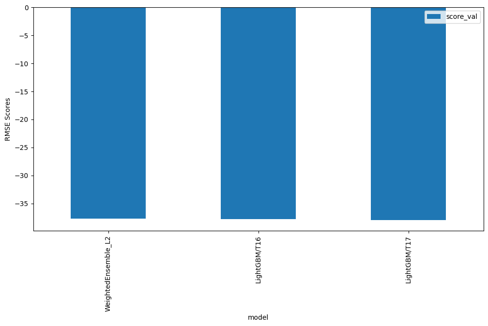

```python
# Output the model's `score_val` in a bar chart to compare performance
leaderboard_new_hpo_df.plot(kind="bar", x="model", y="score_val", figsize=(12, 6))
plt.ylabel("RMSE Scores")
plt.show()
```

```python
predictions_new_hpo = predictor_new_hpo.predict(test)
predictions_new_hpo.head()
```

```
0    19.699509
1     1.959755
2     0.513967
3     1.968776
4     1.959085
Name: count, dtype: float32
```

```python
predictions_new_hpo.describe()
```

```
count    6493.000000
mean      189.821640
std       174.298080
min       -30.513611
25%        46.717613
50%       146.886642
75%       283.469055
max       936.823608
Name: count, dtype: float64
```

```python
# How many negative values do we have?

# Rechecking the predictions in predictions_new_hpo
negative_pred_count = predictions_new_hpo.apply(lambda x: 1 if x<0 else 0)

pred_pos_count = (negative_pred_count==0).sum()
pred_neg_count = (negative_pred_count==1).sum()

print("Total predictions                :", len(predictions_new_hpo.index))
print("Total positive prediction values :", pred_pos_count)
print("Total negative prediction values :", pred_neg_count)
```

```
Total predictions                : 6493
Total positive prediction values : 6382
Total negative prediction values : 111
```

```python
# Remember to set all negative values to zero
predictions_new_hpo[predictions_new_hpo<0] = 0    # (In case, if negative values exist in the predictions_new_hpo, set them to 0)

# Rechecking, if no predictions are less than 0
negative_pred_count = predictions_new_hpo.apply(lambda x: 1 if x<0 else 0)
pred_neg_count = (negative_pred_count==1).sum()
print(f"No. of negative predictions: {pred_neg_count}")
```

```
No. of negative predictions: 0
```

```python
# Same thing as train and test dataset
submission_new_hpo = pd.read_csv('/kaggle/input/bike-sharing-demand/sampleSubmission.csv', parse_dates = ['datetime'])
submission_new_hpo.head()
```

|  | datetime | count |
| --- | --- | --- |
| 0 | 2011-01-20 00:00:00 | 0 |
| 1 | 2011-01-20 01:00:00 | 0 |
| 2 | 2011-01-20 02:00:00 | 0 |
| 3 | 2011-01-20 03:00:00 | 0 |
| 4 | 2011-01-20 04:00:00 | 0 |

```python
# Same submitting predictions
submission_new_hpo["count"] = predictions_new_hpo
submission_new_hpo.to_csv("submission_new_hpo.csv", index=False)
```

```python
!kaggle competitions submit -c bike-sharing-demand -f submission_new_hpo.csv -m "new features with hyperparameters"
```

```
Successfully submitted to Bike Sharing Demand
```

```python
!kaggle competitions submissions -c bike-sharing-demand | tail -n +1 | head -n 6
```

```
fileName                     date                        description                        status                     publicScore  privateScore
---------------------------  --------------------------  ---------------------------------  -------------------------  -----------  ------------
submission_new_hpo.csv       2025-05-14 17:55:11.520000  new features with hyperparameters  SubmissionStatus.COMPLETE  0.55760      0.55760
submission_new_features.csv  2025-05-14 17:26:54.290000  new features                       SubmissionStatus.COMPLETE  0.46797      0.46797
submission.csv               2025-05-14 16:54:51.447000  first raw submission               SubmissionStatus.COMPLETE  1.80448      1.80448
```

#### New Score of 0.55760

**Step 6_1: Hyper parameter optimization**

```python
# Requirements: (Same settings as initial run) For AutoGluon's Tabular Predictions
eval_metric = 'root_mean_squared_error'
label = 'count'
ignored_columns = ["casual", "registered"]   # Ignored columns while training
train_data = train                           # 'casual' and 'registered' columns are already dropped/ignored
time_limit = 600                             # 10 minutes -> 600 seconds
presets = "optimize_for_deployment"          # Lighter preset options (faster)
```

```python
import autogluon.common as ag
## From autogluon documentation:

# Exclude ['NN_TORCH'] family of models
excluded_model_types = ['NN_TORCH']


# Considering GBM, XT and XGB model types (as these along with WeightedEnsembles have shown good results)
# For GBM
gbm_options = [{'extra_trees': True,
                'num_boost_round': ag.space.Int(lower=100, upper=800, default=100),
                'num_leaves': ag.space.Int(lower=26, upper=66, default=36),  # number of leaves in trees (integer hyperparameter)
                'ag_args': {'name_suffix': 'XT'}}, {}, {
        "learning_rate": 0.03,
        "num_leaves": 128,
        "feature_fraction": 0.9,
        "min_data_in_leaf": 3,
        "ag_args": {
            "name_suffix": "Large",
            "priority": 0,
            "hyperparameter_tune_kwargs": None
        }
    }]

# XT Models
xt_options = {'criterion': 'squared_error', 'ag_args': {'name_suffix': 'MSE', 'problem_types': ['regression']}}

# XGB Models
xgb_options = [{'objective': 'reg:squarederror', # 'reg:linear' is deprecated
                'eval_metric': 'rmse',
                'max_depth':ag.space.Int(lower=5, upper=8, default=6),
                'n_estimators': ag.space.Int(lower=100, upper=500, default=100),
                'eta':.3,
                'subsample': 1,
                'colsample_bytree': 1}]

hyperparameters = {  # hyperparameters of each model type
                   'GBM': gbm_options,
                   'XT': xt_options,
                   'XGB': xgb_options
                  }

num_trials = 20            # Number of hyperparameter optimization trials you want to perform
search_strategy = 'auto'  # tune hyperparameters using Bayesian optimization routine with a local scheduler
scheduler = 'local'       # Local FIFO scheduler

hyperparameter_tune_kwargs = {
                            'num_trials': num_trials,
                            'scheduler' : scheduler,
                            'searcher': search_strategy,
                        }

predictor_new_hpo1 = TabularPredictor(label='count', problem_type='regression', eval_metric='root_mean_squared_error',
                                    learner_kwargs={'ignored_columns': ignored_columns}).fit(
                                                                         train_data=train,
                                                                         time_limit=time_limit,
                                                                         presets=presets,
                                                                         hyperparameters=hyperparameters,
                                                                         hyperparameter_tune_kwargs=hyperparameter_tune_kwargs,
                                                                         excluded_model_types=excluded_model_types,
                                                                         refit_full='best')
```

```
No path specified. Models will be saved in: "AutogluonModels/ag-20250514_180749"
Verbosity: 2 (Standard Logging)
=================== System Info ===================
AutoGluon Version:  1.3.0
Python Version:     3.11.11
Operating System:   Linux
Platform Machine:   x86_64
Platform Version:   #1 SMP PREEMPT_DYNAMIC Sun Nov 10 10:07:59 UTC 2024
CPU Count:          4
Memory Avail:       28.61 GB / 31.35 GB (91.3%)
Disk Space Avail:   11.89 GB / 19.52 GB (60.9%)
===================================================
Presets specified: ['optimize_for_deployment']
Warning: hyperparameter tuning is currently experimental and may cause the process to hang.
Beginning AutoGluon training ... Time limit = 600s
AutoGluon will save models to "/kaggle/working/AutogluonModels/ag-20250514_180749"
Train Data Rows:    10886
Train Data Columns: 14
Label Column:       count
Problem Type:       regression
Preprocessing data ...
Using Feature Generators to preprocess the data ...
Dropping user-specified ignored columns: ['casual', 'registered']
Fitting AutoMLPipelineFeatureGenerator...
	Available Memory:                    29298.98 MB
	Train Data (Original)  Memory Usage: 0.61 MB (0.0% of available memory)
	Inferring data type of each feature based on column values. Set feature_metadata_in to manually specify special dtypes of the features.
	Stage 1 Generators:
		Fitting AsTypeFeatureGenerator...
			Note: Converting 3 features to boolean dtype as they only contain 2 unique values.
	Stage 2 Generators:
		Fitting FillNaFeatureGenerator...
	Stage 3 Generators:
		Fitting IdentityFeatureGenerator...
		Fitting CategoryFeatureGenerator...
			Fitting CategoryMemoryMinimizeFeatureGenerator...
	Stage 4 Generators:
		Fitting DropUniqueFeatureGenerator...
	Stage 5 Generators:
		Fitting DropDuplicatesFeatureGenerator...
```

[output cut: 11 more lines]

```
	Train Data (Processed) Memory Usage: 0.44 MB (0.0% of available memory)
Data preprocessing and feature engineering runtime = 0.09s ...
AutoGluon will gauge predictive performance using evaluation metric: 'root_mean_squared_error'
	This metric's sign has been flipped to adhere to being higher_is_better. The metric score can be multiplied by -1 to get the metric value.
	To change this, specify the eval_metric parameter of Predictor()
Automatically generating train/validation split with holdout_frac=0.2, Train Rows: 8708, Val Rows: 2178
User-specified model hyperparameters to be fit:
{
	'GBM': [{'extra_trees': True, 'num_boost_round': Int: lower=100, upper=800, 'num_leaves': Int: lower=26, upper=66, 'ag_args': {'name_suffix': 'XT'}}, {}, {'learning_rate': 0.03, 'num_leaves': 128, 'feature_fraction': 0.9, 'min_data_in_leaf': 3, 'ag_args': {'name_suffix': 'Large', 'priority': 0, 'hy…
	'XT': [{'criterion': 'squared_error', 'ag_args': {'name_suffix': 'MSE', 'problem_types': ['regression']}}],
	'XGB': [{'objective': 'reg:squarederror', 'eval_metric': 'rmse', 'max_depth': Int: lower=5, upper=8, 'n_estimators': Int: lower=100, upper=500, 'eta': 0.3, 'subsample': 1, 'colsample_bytree': 1}],
}
Excluded models: [] (Specified by `excluded_model_types`)
Fitting 5 L1 models, fit_strategy="sequential" ...
Hyperparameter tuning model: LightGBMXT ... Tuning model for up to 107.98s of the 599.91s of remaining time.
```

```
Fitted model: LightGBMXT/T1 ...
	-71.9711	 = Validation score   (-root_mean_squared_error)
	0.46s	 = Training   runtime
	0.01s	 = Validation runtime
Fitted model: LightGBMXT/T2 ...
	-43.8633	 = Validation score   (-root_mean_squared_error)
	0.96s	 = Training   runtime
	0.08s	 = Validation runtime
Fitted model: LightGBMXT/T3 ...
	-88.1544	 = Validation score   (-root_mean_squared_error)
	0.6s	 = Training   runtime
	0.03s	 = Validation runtime
Fitted model: LightGBMXT/T4 ...
	-50.4195	 = Validation score   (-root_mean_squared_error)
	1.48s	 = Training   runtime
	0.15s	 = Validation runtime
Fitted model: LightGBMXT/T5 ...
	-90.0782	 = Validation score   (-root_mean_squared_error)
	0.53s	 = Training   runtime
	0.02s	 = Validation runtime
Fitted model: LightGBMXT/T6 ...
	-58.3299	 = Validation score   (-root_mean_squared_error)
	0.94s	 = Training   runtime
	0.06s	 = Validation runtime
Fitted model: LightGBMXT/T7 ...
	-40.3716	 = Validation score   (-root_mean_squared_error)
	1.57s	 = Training   runtime
	0.18s	 = Validation runtime
Fitted model: LightGBMXT/T8 ...
	-43.8404	 = Validation score   (-root_mean_squared_error)
	1.7s	 = Training   runtime
	0.21s	 = Validation runtime
Fitted model: LightGBMXT/T9 ...
	-52.6528	 = Validation score   (-root_mean_squared_error)
	1.19s	 = Training   runtime
	0.12s	 = Validation runtime
Fitted model: LightGBMXT/T10 ...
	-96.8619	 = Validation score   (-root_mean_squared_error)
	0.78s	 = Training   runtime
	0.04s	 = Validation runtime
```

[output cut: 26 more lines]

```
	1.1s	 = Training   runtime
	0.09s	 = Validation runtime
Fitted model: LightGBMXT/T18 ...
	-42.4013	 = Validation score   (-root_mean_squared_error)
	1.28s	 = Training   runtime
	0.14s	 = Validation runtime
Fitted model: LightGBMXT/T19 ...
	-95.0394	 = Validation score   (-root_mean_squared_error)
	1.08s	 = Training   runtime
	0.08s	 = Validation runtime
Fitted model: LightGBMXT/T20 ...
	-41.5532	 = Validation score   (-root_mean_squared_error)
	1.27s	 = Training   runtime
	0.12s	 = Validation runtime
Hyperparameter tuning model: LightGBM ... Tuning model for up to 107.98s of the 576.12s of remaining time.
```

[output not shown]

```
	Ran out of time, early stopping on iteration 3530. Best iteration is:
	[3527]	valid_set's rmse: 38.0278
	Stopping HPO to satisfy time limit...
Fitted model: LightGBM/T1 ...
	-38.7749	 = Validation score   (-root_mean_squared_error)
	1.8s	 = Training   runtime
	0.17s	 = Validation runtime
Fitted model: LightGBM/T2 ...
	-39.278	 = Validation score   (-root_mean_squared_error)
	1.57s	 = Training   runtime
	0.04s	 = Validation runtime
Fitted model: LightGBM/T3 ...
	-39.6569	 = Validation score   (-root_mean_squared_error)
	2.32s	 = Training   runtime
	0.21s	 = Validation runtime
Fitted model: LightGBM/T4 ...
	-38.124	 = Validation score   (-root_mean_squared_error)
	10.97s	 = Training   runtime
	0.77s	 = Validation runtime
Fitted model: LightGBM/T5 ...
	-39.5392	 = Validation score   (-root_mean_squared_error)
	1.51s	 = Training   runtime
	0.1s	 = Validation runtime
Fitted model: LightGBM/T6 ...
	-39.0408	 = Validation score   (-root_mean_squared_error)
	4.02s	 = Training   runtime
	0.27s	 = Validation runtime
Fitted model: LightGBM/T7 ...
	-38.6204	 = Validation score   (-root_mean_squared_error)
	1.69s	 = Training   runtime
	0.07s	 = Validation runtime
Fitted model: LightGBM/T8 ...
	-39.6364	 = Validation score   (-root_mean_squared_error)
	1.56s	 = Training   runtime
	0.11s	 = Validation runtime
Fitted model: LightGBM/T9 ...
	-38.5911	 = Validation score   (-root_mean_squared_error)
	7.71s	 = Training   runtime
	0.6s	 = Validation runtime
Fitted model: LightGBM/T10 ...
```

[output cut: 23 more lines]

```
Fitted model: LightGBM/T16 ...
	-37.8443	 = Validation score   (-root_mean_squared_error)
	11.86s	 = Training   runtime
	0.94s	 = Validation runtime
Fitted model: LightGBM/T17 ...
	-38.0278	 = Validation score   (-root_mean_squared_error)
	7.97s	 = Training   runtime
	0.72s	 = Validation runtime
Hyperparameter tuning model: ExtraTreesMSE ... Tuning model for up to 107.98s of the 469.61s of remaining time.
	No hyperparameter search space specified for ExtraTreesMSE. Skipping HPO. Will train one model based on the provided hyperparameters.
Fitted model: ExtraTreesMSE ...
	-39.5841	 = Validation score   (-root_mean_squared_error)
	2.11s	 = Training   runtime
	0.5s	 = Validation runtime
Hyperparameter tuning model: XGBoost ... Tuning model for up to 107.98s of the 466.51s of remaining time.
```

[output not shown]

[output cut: 295 more lines]

[output not shown]

```python
predictor_new_hpo1.fit_summary()
```

```
*** Summary of fit() ***
Estimated performance of each model:
                 model  score_val              eval_metric  pred_time_val   fit_time  pred_time_val_marginal  fit_time_marginal  stack_level  can_infer  fit_order
0  WeightedEnsemble_L2 -37.523537  root_mean_squared_error       2.152517  21.946827                0.000458           0.009334            2       True          4
1         LightGBM/T16 -37.844296  root_mean_squared_error       0.937975  11.859864                0.937975          11.859864            1       True          1
2         LightGBM/T17 -38.027770  root_mean_squared_error       0.716813   7.970614                0.716813           7.970614            1       True          2
3        ExtraTreesMSE -39.584076  root_mean_squared_error       0.497272   2.107015                0.497272           2.107015            1       True          3
Number of models trained: 4
Types of models trained:
{'WeightedEnsembleModel', 'XTModel', 'LGBModel'}
Bagging used: False
Multi-layer stack-ensembling used: False
Feature Metadata (Processed):
(raw dtype, special dtypes):
('category', [])  : 3 | ['season', 'weather', 'day_type']
('float', [])     : 2 | ['temp', 'windspeed']
('int', [])       : 4 | ['humidity', 'month', 'day', 'hour']
('int', ['bool']) : 3 | ['holiday', 'workingday', 'year']
*** End of fit() summary ***
```

```
{'model_types': {'LightGBM/T16': 'LGBModel',
  'LightGBM/T17': 'LGBModel',
  'ExtraTreesMSE': 'XTModel',
  'WeightedEnsemble_L2': 'WeightedEnsembleModel'},
 'model_performance': {'LightGBM/T16': -37.8442961045261,
  'LightGBM/T17': -38.0277701573186,
  'ExtraTreesMSE': -39.58407605032568,
  'WeightedEnsemble_L2': -37.523536996808886},
 'model_best': 'WeightedEnsemble_L2',
 'model_paths': {'LightGBM/T16': ['LightGBM', 'T16'],
  'LightGBM/T17': ['LightGBM', 'T17'],
  'ExtraTreesMSE': ['ExtraTreesMSE'],
  'WeightedEnsemble_L2': ['WeightedEnsemble_L2']},
 'model_fit_times': {'LightGBM/T16': 11.859864234924316,
  'LightGBM/T17': 7.970613956451416,
  'ExtraTreesMSE': 2.1070148944854736,
  'WeightedEnsemble_L2': 0.009334325790405273},
 'model_pred_times': {'LightGBM/T16': 0.9379749298095703,
  'LightGBM/T17': 0.7168126106262207,
  'ExtraTreesMSE': 0.4972715377807617,
  'WeightedEnsemble_L2': 0.0004582405090332031},
 'num_bag_folds': 0,
 'max_stack_level': 2,
 'model_hyperparams': {'LightGBM/T16': {'learning_rate': 0.00804484475314037,
   'feature_fraction': 0.8025956402684602,
   'min_data_in_leaf': 16,
   'num_leaves': 69},
  'LightGBM/T17': {'learning_rate': 0.005761424070803828,
   'feature_fraction': 0.8312618072520881,
   'min_data_in_leaf': 13,
   'num_leaves': 84},
  'ExtraTreesMSE': {'n_estimators': 300,
   'max_leaf_nodes': 15000,
   'n_jobs': -1,
   'random_state': 0,
   'bootstrap': True,
   'criterion': 'squared_error'},
  'WeightedEnsemble_L2': {'use_orig_features': False,
   'valid_stacker': True,
   'max_base_models': 0,
   'max_base_models_per_type': 'auto',
   'save_bag_folds': True,
   'stratify': 'auto',
   'bin': 'auto',
   'n_bins': None}},
 'leaderboard':                  model  score_val              eval_metric  pred_time_val  \
 0  WeightedEnsemble_L2 -37.523537  root_mean_squared_error       2.152517
 1         LightGBM/T16 -37.844296  root_mean_squared_error       0.937975
 2         LightGBM/T17 -38.027770  root_mean_squared_error       0.716813
 3        ExtraTreesMSE -39.584076  root_mean_squared_error       0.497272

     fit_time  pred_time_val_marginal  fit_time_marginal  stack_level  \
 0  21.946827                0.000458           0.009334            2
 1  11.859864                0.937975          11.859864            1
 2   7.970614                0.716813           7.970614            1
 3   2.107015                0.497272           2.107015            1

    can_infer  fit_order
 0       True          4
 1       True          1
 2       True          2
 3       True          3  }
```

```python
# Leaderboard dataframe
leaderboard_new_hpo1_df = pd.DataFrame(predictor_new_hpo1.leaderboard(silent=True))
leaderboard_new_hpo1_df
```

|  | model | score_val | eval_metric | pred_time_val | fit_time | pred_time_val_marginal | fit_time_marginal | stack_level | can_infer | fit_order |
| --- | --- | --- | --- | --- | --- | --- | --- | --- | --- | --- |
| 0 | WeightedEnsemble_L2 | -37.523537 | root_mean_squared_error | 2.152517 | 21.946827 | 0.000458 | 0.009334 | 2 | True | 4 |
| 1 | LightGBM/T16 | -37.844296 | root_mean_squared_error | 0.937975 | 11.859864 | 0.937975 | 11.859864 | 1 | True | 1 |
| 2 | LightGBM/T17 | -38.027770 | root_mean_squared_error | 0.716813 | 7.970614 | 0.716813 | 7.970614 | 1 | True | 2 |
| 3 | ExtraTreesMSE | -39.584076 | root_mean_squared_error | 0.497272 | 2.107015 | 0.497272 | 2.107015 | 1 | True | 3 |

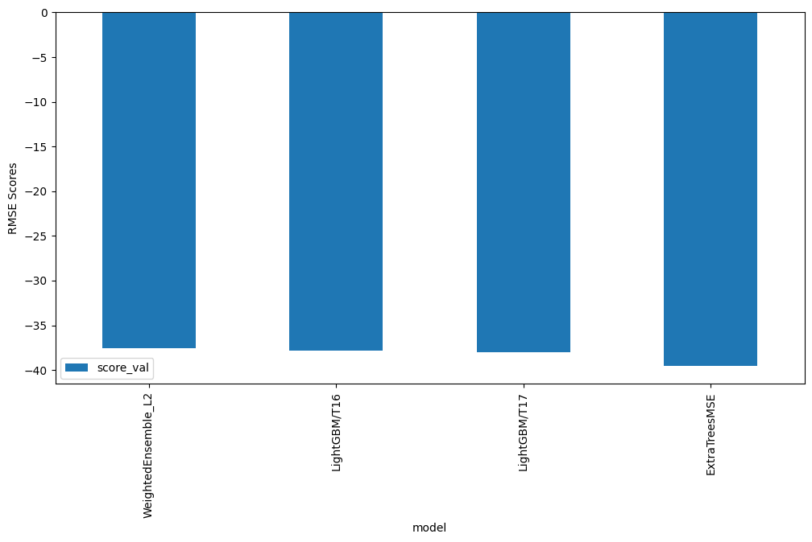

```python
# Output the model's `score_val` in a bar chart to compare performance

leaderboard_new_hpo1_df.plot(kind="bar", x="model", y="score_val", figsize=(12, 6))
plt.ylabel("RMSE Scores")
plt.show()
```

```python
predictions_new_hpo1 = predictor_new_hpo1.predict(test)
predictions_new_hpo1.head()
```

```
0    18.242865
1     2.270455
2     0.453414
3     2.156645
4     2.207362
Name: count, dtype: float32
```

```python
# How many negative values do we have?

# Rechecking the predictions in predictions_new_hpo1
negative_pred_count = predictions_new_hpo1.apply(lambda x: 1 if x<0 else 0)

pred_pos_count = (negative_pred_count==0).sum()
pred_neg_count = (negative_pred_count==1).sum()

print("Total predictions                :", len(predictions_new_hpo1.index))
print("Total positive prediction values :", pred_pos_count)
print("Total negative prediction values :", pred_neg_count)
```

```
Total predictions                : 6493
Total positive prediction values : 6421
Total negative prediction values : 72
```

```python
# Remember to set all negative values to zero
predictions_new_hpo1[predictions_new_hpo1<0] = 0    # (In case, if negative values exist in the predictions_new_hpo1, set them to 0)

# Rechecking, if no predictions are less than 0
negative_pred_count = predictions_new_hpo1.apply(lambda x: 1 if x<0 else 0)
pred_neg_count = (negative_pred_count==1).sum()
print(f"No.of negative predictions: {pred_neg_count}")
```

```
No.of negative predictions: 0
```

```python
# Same thing as train and test dataset
submission_new_hpo1 = pd.read_csv('/kaggle/input/bike-sharing-demand/sampleSubmission.csv', parse_dates = ['datetime'])
submission_new_hpo1.head()
```

|  | datetime | count |
| --- | --- | --- |
| 0 | 2011-01-20 00:00:00 | 0 |
| 1 | 2011-01-20 01:00:00 | 0 |
| 2 | 2011-01-20 02:00:00 | 0 |
| 3 | 2011-01-20 03:00:00 | 0 |
| 4 | 2011-01-20 04:00:00 | 0 |

```python
# Same submitting predictions
submission_new_hpo1["count"] = predictions_new_hpo1
submission_new_hpo1.to_csv("submission_new_hpo1.csv", index=False)
```

```python
!kaggle competitions submit -c bike-sharing-demand -f submission_new_hpo1.csv -m "new features with hyperparameters 1"
```

```
Successfully submitted to Bike Sharing Demand
```

```python
!kaggle competitions submissions -c bike-sharing-demand | tail -n +1 | head -n 6
```

```
fileName                     date                        description                          status                     publicScore  privateScore
---------------------------  --------------------------  -----------------------------------  -------------------------  -----------  ------------
submission_new_hpo1.csv      2025-05-14 18:12:42.563000  new features with hyperparameters 1  SubmissionStatus.COMPLETE  0.52258      0.52258
submission_new_hpo.csv       2025-05-14 17:55:11.520000  new features with hyperparameters    SubmissionStatus.COMPLETE  0.55760      0.55760
submission_new_features.csv  2025-05-14 17:26:54.290000  new features                         SubmissionStatus.COMPLETE  0.46797      0.46797
submission.csv               2025-05-14 16:54:51.447000  first raw submission                 SubmissionStatus.COMPLETE  1.80448      1.80448
```

**New Score of** 0.52258

**Step 6_2: Hyper parameter optimization**

```python
# Requirements: (Same settings as initial run) For AutoGluon's Tabular Predictions
eval_metric = 'root_mean_squared_error'
label = 'count'
ignored_columns = ["casual", "registered"]   # Ignored columns while training
train_data = train                           # 'casual' and 'registered' columns are already dropped/ignored
time_limit = 600                             # 10 minutes -> 600 seconds
presets = "optimize_for_deployment"
```

```python
import autogluon.common as ag
## From autogluon documentation

# Exclude ['NN_TORCH'] family of models
excluded_model_types = ['NN_TORCH']


# Considering GBM, XT, XGB, KNN and RF model types (as these along with WeightedEnsembles have shown good results in the past)
# For GBM
gbm_options = [{'extra_trees': True,
                'num_boost_round': ag.space.Int(lower=100, upper=800, default=100),
                'num_leaves': ag.space.Int(lower=26, upper=66, default=36),  # number of leaves in trees (integer hyperparameter)
                'ag_args': {'name_suffix': 'XT'}}, {}, {
        "learning_rate": 0.03,
        "num_leaves": 128,
        "feature_fraction": 0.9,
        "min_data_in_leaf": 3,
        "ag_args": {
            "name_suffix": "Large",
            "priority": 0,
            "hyperparameter_tune_kwargs": None
        }
    }]
# XT Models
xt_options = {'criterion': 'squared_error', 'ag_args': {'name_suffix': 'MSE', 'problem_types': ['regression']}}
# XGB Models
xgb_options = [{'objective': 'reg:squarederror', # 'reg:linear' is deprecated
                'eval_metric': 'rmse',
                'max_depth':ag.space.Int(lower=5, upper=8, default=6),
                'n_estimators': ag.space.Int(lower=100, upper=500, default=100),
                'eta':.3,
                'subsample': 1,
                'colsample_bytree': 1}]
# Random Forest Models
rf_options = {'criterion': 'squared_error', 'ag_args': {'name_suffix': 'MSE', 'problem_types': ['regression']}}
# KNN
knn_options = [{'weights': 'uniform', 'ag_args': {'name_suffix': 'Uniform'}},
               {'weights': 'distance', 'ag_args': {'name_suffix': 'Distance'}}]  # default

hyperparameters = {  # hyperparameters of each model type
                   'GBM': gbm_options,
                   'KNN': knn_options,
                   'XT': xt_options,
                   'XGB': xgb_options,
                   'RF': rf_options
                  }


num_trials = 20            # Number of hyperparameter optimization trials you want to perform
search_strategy = 'auto'  # tune hyperparameters using Bayesian optimization routine with a local scheduler
scheduler = 'local'       # Local FIFO scheduler

hyperparameter_tune_kwargs = {
                            'num_trials': num_trials,
                            'scheduler' : scheduler,
                            'searcher': search_strategy,
                        }


predictor_new_hpo2 = TabularPredictor(label='count', problem_type='regression', eval_metric='root_mean_squared_error',
                                    learner_kwargs={'ignored_columns': ignored_columns}).fit(
                                                                         train_data=train,
                                                                         time_limit=time_limit,
                                                                         presets=presets,
                                                                         hyperparameters=hyperparameters,
                                                                         hyperparameter_tune_kwargs=hyperparameter_tune_kwargs,
                                                                         excluded_model_types=excluded_model_types,
                                                                         refit_full='best')
```

```
No path specified. Models will be saved in: "AutogluonModels/ag-20250514_181442"
Verbosity: 2 (Standard Logging)
=================== System Info ===================
AutoGluon Version:  1.3.0
Python Version:     3.11.11
Operating System:   Linux
Platform Machine:   x86_64
Platform Version:   #1 SMP PREEMPT_DYNAMIC Sun Nov 10 10:07:59 UTC 2024
CPU Count:          4
Memory Avail:       28.57 GB / 31.35 GB (91.1%)
Disk Space Avail:   11.65 GB / 19.52 GB (59.7%)
===================================================
Presets specified: ['optimize_for_deployment']
Warning: hyperparameter tuning is currently experimental and may cause the process to hang.
Beginning AutoGluon training ... Time limit = 600s
AutoGluon will save models to "/kaggle/working/AutogluonModels/ag-20250514_181442"
Train Data Rows:    10886
Train Data Columns: 14
Label Column:       count
Problem Type:       regression
Preprocessing data ...
Using Feature Generators to preprocess the data ...
Dropping user-specified ignored columns: ['casual', 'registered']
Fitting AutoMLPipelineFeatureGenerator...
	Available Memory:                    29252.84 MB
	Train Data (Original)  Memory Usage: 0.61 MB (0.0% of available memory)
	Inferring data type of each feature based on column values. Set feature_metadata_in to manually specify special dtypes of the features.
	Stage 1 Generators:
		Fitting AsTypeFeatureGenerator...
			Note: Converting 3 features to boolean dtype as they only contain 2 unique values.
	Stage 2 Generators:
		Fitting FillNaFeatureGenerator...
	Stage 3 Generators:
		Fitting IdentityFeatureGenerator...
		Fitting CategoryFeatureGenerator...
			Fitting CategoryMemoryMinimizeFeatureGenerator...
	Stage 4 Generators:
		Fitting DropUniqueFeatureGenerator...
	Stage 5 Generators:
		Fitting DropDuplicatesFeatureGenerator...
```

[output cut: 25 more lines]

```
Excluded models: [] (Specified by `excluded_model_types`)
Fitting 8 L1 models, fit_strategy="sequential" ...
Hyperparameter tuning model: KNeighborsUniform ... Tuning model for up to 67.49s of the 599.9s of remaining time.
	No hyperparameter search space specified for KNeighborsUniform. Skipping HPO. Will train one model based on the provided hyperparameters.
Fitted model: KNeighborsUniform ...
	-115.5161	 = Validation score   (-root_mean_squared_error)
	0.01s	 = Training   runtime
	0.04s	 = Validation runtime
Hyperparameter tuning model: KNeighborsDistance ... Tuning model for up to 67.49s of the 599.84s of remaining time.
	No hyperparameter search space specified for KNeighborsDistance. Skipping HPO. Will train one model based on the provided hyperparameters.
Fitted model: KNeighborsDistance ...
	-112.4591	 = Validation score   (-root_mean_squared_error)
	0.01s	 = Training   runtime
	0.04s	 = Validation runtime
Hyperparameter tuning model: LightGBMXT ... Tuning model for up to 67.49s of the 599.78s of remaining time.
```

```
Fitted model: LightGBMXT/T1 ...
	-71.9711	 = Validation score   (-root_mean_squared_error)
	0.52s	 = Training   runtime
	0.01s	 = Validation runtime
Fitted model: LightGBMXT/T2 ...
	-43.8633	 = Validation score   (-root_mean_squared_error)
	0.91s	 = Training   runtime
	0.07s	 = Validation runtime
Fitted model: LightGBMXT/T3 ...
	-88.1544	 = Validation score   (-root_mean_squared_error)
	0.57s	 = Training   runtime
	0.03s	 = Validation runtime
Fitted model: LightGBMXT/T4 ...
	-50.4195	 = Validation score   (-root_mean_squared_error)
	1.44s	 = Training   runtime
	0.15s	 = Validation runtime
Fitted model: LightGBMXT/T5 ...
	-90.0782	 = Validation score   (-root_mean_squared_error)
	0.53s	 = Training   runtime
	0.02s	 = Validation runtime
Fitted model: LightGBMXT/T6 ...
	-58.3299	 = Validation score   (-root_mean_squared_error)
	0.92s	 = Training   runtime
	0.06s	 = Validation runtime
Fitted model: LightGBMXT/T7 ...
	-40.3716	 = Validation score   (-root_mean_squared_error)
	1.55s	 = Training   runtime
	0.18s	 = Validation runtime
Fitted model: LightGBMXT/T8 ...
	-43.8404	 = Validation score   (-root_mean_squared_error)
	1.71s	 = Training   runtime
	0.2s	 = Validation runtime
Fitted model: LightGBMXT/T9 ...
	-52.6528	 = Validation score   (-root_mean_squared_error)
	1.18s	 = Training   runtime
	0.13s	 = Validation runtime
Fitted model: LightGBMXT/T10 ...
	-96.8619	 = Validation score   (-root_mean_squared_error)
	0.76s	 = Training   runtime
	0.04s	 = Validation runtime
```

[output cut: 26 more lines]

```
	1.06s	 = Training   runtime
	0.09s	 = Validation runtime
Fitted model: LightGBMXT/T18 ...
	-42.4013	 = Validation score   (-root_mean_squared_error)
	1.35s	 = Training   runtime
	0.14s	 = Validation runtime
Fitted model: LightGBMXT/T19 ...
	-95.0394	 = Validation score   (-root_mean_squared_error)
	1.03s	 = Training   runtime
	0.08s	 = Validation runtime
Fitted model: LightGBMXT/T20 ...
	-41.5532	 = Validation score   (-root_mean_squared_error)
	1.28s	 = Training   runtime
	0.12s	 = Validation runtime
Hyperparameter tuning model: LightGBM ... Tuning model for up to 67.49s of the 576.94s of remaining time.
```

[output not shown]

```
	Ran out of time, early stopping on iteration 802. Best iteration is:
	[802]	valid_set's rmse: 41.1954
Fitted model: LightGBM/T1 ...
	-38.7749	 = Validation score   (-root_mean_squared_error)
	1.83s	 = Training   runtime
	0.17s	 = Validation runtime
Fitted model: LightGBM/T2 ...
	-39.278	 = Validation score   (-root_mean_squared_error)
	1.51s	 = Training   runtime
	0.04s	 = Validation runtime
Fitted model: LightGBM/T3 ...
	-39.6569	 = Validation score   (-root_mean_squared_error)
	2.25s	 = Training   runtime
	0.22s	 = Validation runtime
Fitted model: LightGBM/T4 ...
	-38.124	 = Validation score   (-root_mean_squared_error)
	10.43s	 = Training   runtime
	0.75s	 = Validation runtime
Fitted model: LightGBM/T5 ...
	-39.5392	 = Validation score   (-root_mean_squared_error)
	1.48s	 = Training   runtime
	0.1s	 = Validation runtime
Fitted model: LightGBM/T6 ...
	-39.0408	 = Validation score   (-root_mean_squared_error)
	3.76s	 = Training   runtime
	0.27s	 = Validation runtime
Fitted model: LightGBM/T7 ...
	-38.6204	 = Validation score   (-root_mean_squared_error)
	1.85s	 = Training   runtime
	0.08s	 = Validation runtime
Fitted model: LightGBM/T8 ...
	-39.6364	 = Validation score   (-root_mean_squared_error)
	1.55s	 = Training   runtime
	0.11s	 = Validation runtime
Fitted model: LightGBM/T9 ...
	-38.5911	 = Validation score   (-root_mean_squared_error)
	7.49s	 = Training   runtime
	0.57s	 = Validation runtime
Fitted model: LightGBM/T10 ...
	-38.5597	 = Validation score   (-root_mean_squared_error)
```

[output cut: 16 more lines]

```
	1.56s	 = Training   runtime
	0.1s	 = Validation runtime
Hyperparameter tuning model: RandomForestMSE ... Tuning model for up to 67.49s of the 513.29s of remaining time.
	No hyperparameter search space specified for RandomForestMSE. Skipping HPO. Will train one model based on the provided hyperparameters.
Fitted model: RandomForestMSE ...
	-41.0484	 = Validation score   (-root_mean_squared_error)
	3.68s	 = Training   runtime
	0.51s	 = Validation runtime
Hyperparameter tuning model: ExtraTreesMSE ... Tuning model for up to 67.49s of the 508.6s of remaining time.
	No hyperparameter search space specified for ExtraTreesMSE. Skipping HPO. Will train one model based on the provided hyperparameters.
Fitted model: ExtraTreesMSE ...
	-39.5841	 = Validation score   (-root_mean_squared_error)
	2.12s	 = Training   runtime
	0.5s	 = Validation runtime
Hyperparameter tuning model: XGBoost ... Tuning model for up to 67.49s of the 505.58s of remaining time.
```

[output not shown]

[output cut: 295 more lines]

[output not shown]

```python
predictor_new_hpo2.fit_summary()
```

```
*** Summary of fit() ***
Estimated performance of each model:
                 model  score_val              eval_metric  pred_time_val   fit_time  pred_time_val_marginal  fit_time_marginal  stack_level  can_infer  fit_order
0  WeightedEnsemble_L2 -37.797224  root_mean_squared_error       1.681214  17.661988                0.000454           0.013088            2       True          4
1          LightGBM/T4 -38.124006  root_mean_squared_error       0.753657  10.431830                0.753657          10.431830            1       True          1
2         LightGBM/T11 -38.228328  root_mean_squared_error       0.425215   5.101739                0.425215           5.101739            1       True          2
3        ExtraTreesMSE -39.584076  root_mean_squared_error       0.501888   2.115331                0.501888           2.115331            1       True          3
Number of models trained: 4
Types of models trained:
{'WeightedEnsembleModel', 'XTModel', 'LGBModel'}
Bagging used: False
Multi-layer stack-ensembling used: False
Feature Metadata (Processed):
(raw dtype, special dtypes):
('category', [])  : 3 | ['season', 'weather', 'day_type']
('float', [])     : 2 | ['temp', 'windspeed']
('int', [])       : 4 | ['humidity', 'month', 'day', 'hour']
('int', ['bool']) : 3 | ['holiday', 'workingday', 'year']
*** End of fit() summary ***
```

```
{'model_types': {'LightGBM/T4': 'LGBModel',
  'LightGBM/T11': 'LGBModel',
  'ExtraTreesMSE': 'XTModel',
  'WeightedEnsemble_L2': 'WeightedEnsembleModel'},
 'model_performance': {'LightGBM/T4': -38.12400606131232,
  'LightGBM/T11': -38.22832821272466,
  'ExtraTreesMSE': -39.58407605032568,
  'WeightedEnsemble_L2': -37.7972241600116},
 'model_best': 'WeightedEnsemble_L2',
 'model_paths': {'LightGBM/T4': ['LightGBM', 'T4'],
  'LightGBM/T11': ['LightGBM', 'T11'],
  'ExtraTreesMSE': ['ExtraTreesMSE'],
  'WeightedEnsemble_L2': ['WeightedEnsemble_L2']},
 'model_fit_times': {'LightGBM/T4': 10.431829929351807,
  'LightGBM/T11': 5.101739406585693,
  'ExtraTreesMSE': 2.115330696105957,
  'WeightedEnsemble_L2': 0.013088464736938477},
 'model_pred_times': {'LightGBM/T4': 0.7536571025848389,
  'LightGBM/T11': 0.4252145290374756,
  'ExtraTreesMSE': 0.5018877983093262,
  'WeightedEnsemble_L2': 0.0004544258117675781},
 'num_bag_folds': 0,
 'max_stack_level': 2,
 'model_hyperparams': {'LightGBM/T4': {'learning_rate': 0.006163502781172818,
   'feature_fraction': 0.824383651636118,
   'min_data_in_leaf': 14,
   'num_leaves': 74},
  'LightGBM/T11': {'learning_rate': 0.013267954269430244,
   'feature_fraction': 0.8536654849976308,
   'min_data_in_leaf': 13,
   'num_leaves': 71},
  'ExtraTreesMSE': {'n_estimators': 300,
   'max_leaf_nodes': 15000,
   'n_jobs': -1,
   'random_state': 0,
   'bootstrap': True,
   'criterion': 'squared_error'},
  'WeightedEnsemble_L2': {'use_orig_features': False,
   'valid_stacker': True,
   'max_base_models': 0,
   'max_base_models_per_type': 'auto',
   'save_bag_folds': True,
   'stratify': 'auto',
   'bin': 'auto',
   'n_bins': None}},
 'leaderboard':                  model  score_val              eval_metric  pred_time_val  \
 0  WeightedEnsemble_L2 -37.797224  root_mean_squared_error       1.681214
 1          LightGBM/T4 -38.124006  root_mean_squared_error       0.753657
 2         LightGBM/T11 -38.228328  root_mean_squared_error       0.425215
 3        ExtraTreesMSE -39.584076  root_mean_squared_error       0.501888

     fit_time  pred_time_val_marginal  fit_time_marginal  stack_level  \
 0  17.661988                0.000454           0.013088            2
 1  10.431830                0.753657          10.431830            1
 2   5.101739                0.425215           5.101739            1
 3   2.115331                0.501888           2.115331            1

    can_infer  fit_order
 0       True          4
 1       True          1
 2       True          2
 3       True          3  }
```

```python
# Leaderboard dataframe
leaderboard_new_hpo2_df = pd.DataFrame(predictor_new_hpo2.leaderboard(silent=True))
leaderboard_new_hpo2_df
```

|  | model | score_val | eval_metric | pred_time_val | fit_time | pred_time_val_marginal | fit_time_marginal | stack_level | can_infer | fit_order |
| --- | --- | --- | --- | --- | --- | --- | --- | --- | --- | --- |
| 0 | WeightedEnsemble_L2 | -37.797224 | root_mean_squared_error | 1.681214 | 17.661988 | 0.000454 | 0.013088 | 2 | True | 4 |
| 1 | LightGBM/T4 | -38.124006 | root_mean_squared_error | 0.753657 | 10.431830 | 0.753657 | 10.431830 | 1 | True | 1 |
| 2 | LightGBM/T11 | -38.228328 | root_mean_squared_error | 0.425215 | 5.101739 | 0.425215 | 5.101739 | 1 | True | 2 |
| 3 | ExtraTreesMSE | -39.584076 | root_mean_squared_error | 0.501888 | 2.115331 | 0.501888 | 2.115331 | 1 | True | 3 |

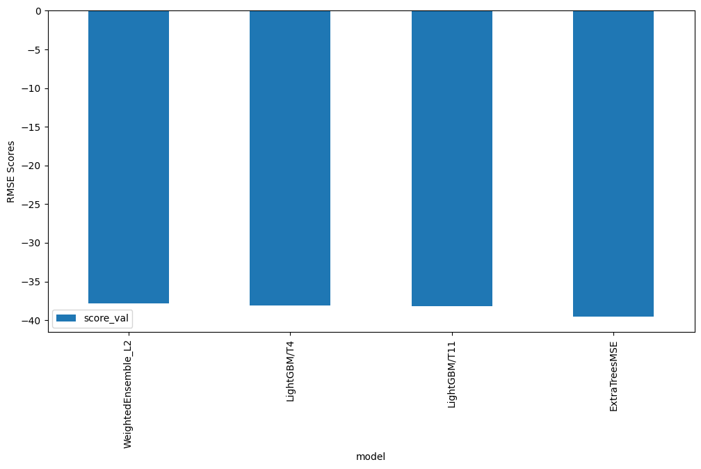

```python
leaderboard_new_hpo2_df.plot(kind="bar", x="model", y="score_val", figsize=(12, 6))
plt.ylabel("RMSE Scores")
plt.show()
```

```python
predictions_new_hpo2 = predictor_new_hpo2.predict(test)
predictions_new_hpo2.head()
```

```
0    15.125503
1     3.677229
2     2.225937
3     1.853711
4     1.859155
Name: count, dtype: float32
```

```python
# How many negative values do we have?

# Rechecking the predictions in predictions_new_hpo2
negative_pred_count = predictions_new_hpo2.apply(lambda x: 1 if x<0 else 0)

pred_pos_count = (negative_pred_count==0).sum()
pred_neg_count = (negative_pred_count==1).sum()

print("Total predictions                :", len(predictions_new_hpo2.index))
print("Total positive prediction values :", pred_pos_count)
print("Total negative prediction values :", pred_neg_count)
```

```
Total predictions                : 6493
Total positive prediction values : 6430
Total negative prediction values : 63
```

```python
# Remember to set all negative values to zero
predictions_new_hpo2[predictions_new_hpo2<0] = 0    # (In case, if negative values exist in the predictions_new_hpo2, set them to 0)

# Rechecking, if no predictions are less than 0
negative_pred_count = predictions_new_hpo2.apply(lambda x: 1 if x<0 else 0)
pred_neg_count = (negative_pred_count==1).sum()
print(f"No. of negative predictions: {pred_neg_count}")
```

```
No. of negative predictions: 0
```

```python
# Same thing as train and test dataset
submission_new_hpo2 = pd.read_csv('/kaggle/input/bike-sharing-demand/sampleSubmission.csv', parse_dates = ['datetime'])
submission_new_hpo2.head()
```

|  | datetime | count |
| --- | --- | --- |
| 0 | 2011-01-20 00:00:00 | 0 |
| 1 | 2011-01-20 01:00:00 | 0 |
| 2 | 2011-01-20 02:00:00 | 0 |
| 3 | 2011-01-20 03:00:00 | 0 |
| 4 | 2011-01-20 04:00:00 | 0 |

```python
# Same submitting predictions
submission_new_hpo2["count"] = predictions_new_hpo2
submission_new_hpo2.to_csv("submission_new_hpo2.csv", index=False)
```

```python
!kaggle competitions submit -c bike-sharing-demand -f submission_new_hpo2.csv -m "new features with hyperparameters 2"
```

```
Successfully submitted to Bike Sharing Demand
```

```python
!kaggle competitions submissions -c bike-sharing-demand | tail -n +1 | head -n 7
```

```
fileName                     date                        description                          status                     publicScore  privateScore
---------------------------  --------------------------  -----------------------------------  -------------------------  -----------  ------------
submission_new_hpo2.csv      2025-05-14 18:18:04.507000  new features with hyperparameters 2  SubmissionStatus.COMPLETE  0.51152      0.51152
submission_new_hpo1.csv      2025-05-14 18:12:42.563000  new features with hyperparameters 1  SubmissionStatus.COMPLETE  0.52258      0.52258
submission_new_hpo.csv       2025-05-14 17:55:11.520000  new features with hyperparameters    SubmissionStatus.COMPLETE  0.55760      0.55760
submission_new_features.csv  2025-05-14 17:26:54.290000  new features                         SubmissionStatus.COMPLETE  0.46797      0.46797
submission.csv               2025-05-14 16:54:51.447000  first raw submission                 SubmissionStatus.COMPLETE  1.80448      1.80448
```

**New Score of** 0.51152

## Step 7: Write a Report

### Refer to the markdown file for the full report

### Creating plots and table for report

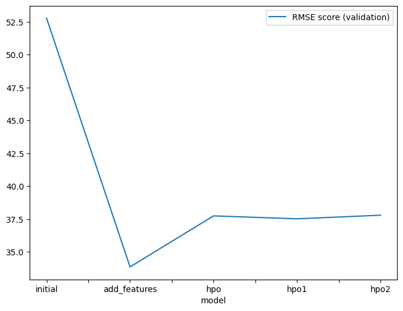

```python
fig = pd.DataFrame(
    {
        "model": ["initial", "add_features", "hpo", "hpo1", "hpo2"],
        "RMSE score (validation)": [52.770755, 33.868672, 37.746321, 37.523537, 37.797224]  # Note: Actual RMSE values are considered
    }
).plot(x="model", y="RMSE score (validation)", figsize=(8, 6)).get_figure()
fig.savefig('/kaggle/working/model_train_score.png')
```

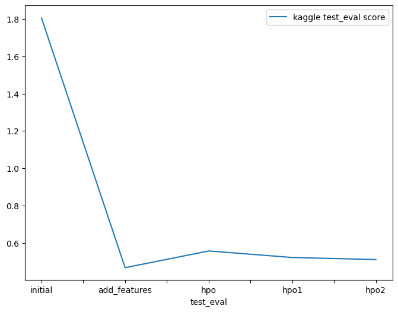

```python
# Take the 3 kaggle scores (or more) and create a line plot to show improvement
fig = pd.DataFrame(
    {
        "test_eval": ["initial", "add_features", "hpo", "hpo1", "hpo2"],
        "kaggle test_eval score": [1.80448, 0.46797 , 0.55760,0.52258,0.51152]
    }
).plot(x="test_eval", y="kaggle test_eval score", figsize=(8, 6)).get_figure()
fig.savefig('/kaggle/working/model_test_score.png')
```

### Hyperparameter table

```python
# The 3 hyperparameters we tuned with the kaggle score as the result

# NOTE: Here the last 'hpo' based top-model is the 'hpo2' model with best Kaggle score within hyperparameter optimization category
pd.DataFrame({
    "model": ["initial", "add_features", "hpo (top-hpo-model: hpo2)"],
    "hpo1": ["prescribed_values", "prescribed_values", "Tree-Based Models: (GBM, XT, XGB & RF)"],
    "hpo2": ["prescribed_values", "prescribed_values", "KNN"],
    "hpo3": ["presets: 'high quality' (auto_stack=True)", "presets: 'high quality' (auto_stack=True)", "presets: 'optimize_for_deployment"],
    "score": [1.80448, 0.46797 , 0.51152 ]
})
```

|  | model | hpo1 | hpo2 | hpo3 | score |
| --- | --- | --- | --- | --- | --- |
| 0 | initial | prescribed_values | prescribed_values | presets: 'high quality' (auto_stack=True) | 1.80448 |
| 1 | add_features | prescribed_values | prescribed_values | presets: 'high quality' (auto_stack=True) | 0.46797 |
| 2 | hpo (top-hpo-model: hpo2) | Tree-Based Models: (GBM, XT, XGB & RF) | KNN | presets: 'optimize_for_deployment | 0.51152 |